# Project - PWD

## B.Sc. EXAMINATION OF COMPUTER SCIENCE

### CM2015 Programming with Data

#### Author Student Number: 200409407

#### 2022 / 2023

# Understanding Cybersecurity Breaches: A Python Jupyter Notebook Analysis

### ABSTRACT

**BACKGROUND**: The background of this study orbits around analysing a dataset spanning four years from 2019 to 2022, which contains information on cybersecurity incidents and data breaches. The dataset provides insights into the types of incidents, affected data subjects, sectors targeted, and other relevant information.

**OBJECTIVE:** The objective of this study is to gain a comprehensive understanding of the cybersecurity landscape based on the provided dataset. The aim is to identify trends, patterns, and key insights related to incident types, data subjects affected, sectors targeted, and the response to these incidents.

**METHOD:** The analysis of the dataset involved web scraping to collect data from the pwned webpage and various data cleaning techniques to ensure data quality. The dataset was explored to understand its structure and variables. Different visualisation techniques, such as bar charts, line plots, and tables, were used to analyse and present the data effectively. Attention was given to accuracy and reliability through data cleaning and validation techniques. Overall, web scraping, data cleaning, and visualisation techniques were key components of the analysis.

**RESULTS:** The analysis of the dataset uncovered significant insights. Notably, 2019 emerged as the year with the highest number of data breaches, based on the pwned webpage. Over time, there was a gradual decrease in cyberattacks, with a noteworthy rise in incidents during the third quarter (Q3) of each year. Phishing incidents were found to be particularly prevalent among the various types of attacks investigated. The study identified basic personal identifiers as the most commonly compromised data type in the analysed breaches. Sectors such as education and childcare, retail and manufacturing, finance, insurance, credit, general business, and the legal sector experienced a higher frequency of cyberattacks.

On average, each incident impacted approximately 5,168 individuals. The analysis also considered the reporting time for breaches, revealing an average of 41.0 hours. It should be noted that a percentage of breaches exceeded the designated reporting timeframe. The findings underscored the significance of prompt decision-making and timely response in effectively addressing cybersecurity incidents. Taking swift action can help mitigate the repercussions of breaches and safeguard individuals and organisations from further harm.

**CONCLUSION:** In conclusion, this study provides valuable insights into the cybersecurity landscape based on the analysed dataset. The results emphasise how important it is to protect basic personal information by implementing strong security measures and raising awareness about phishing attacks within organisations. The findings also emphasise the need for prompt reporting, investigation, and appropriate action to mitigate the impact of cyber incidents. These insights can guide organisations and individuals towards strengthening their cybersecurity defences and responding effectively to potential threats.

1. **Introduction**
2. **Project background and aims**

   2.1 Background

   2.2 Aims and Objectives
3. **Data aquisition**

   3.1 Publicly Available Datasets

   3.2 Data limitations

   3.3 Data Cleaning and Preprocessing
4. **Analysis**

   4.1 Explanatory Analysis

   4.1.1 Univariate analysis

   4.1.2 Bivariable analysis

   4.2 Web Scraping
5. **Conclusion and critical evaluation**
6. **Ethical Statement**
7. **References**
8. **Glossary**

## *Introduction*

For Parmar (2018), in today's interconnected world, where information flows freely across digital networks, the importance of cybersecurity cannot be overstated. Cybersecurity breaches, which embrace a wide range of malicious activities targeting computer systems, networks, and data, have become an ever-growing concern for individuals, organisations, and governments alike. These breaches not only compromise sensitive information but also have the potential to disrupt critical infrastructure, cause financial losses, and even threaten national security.

Craig et al. (2015), add that cybercriminals constantly evolve their tactics, exploiting sophisticated techniques to take advantage of vulnerabilities and infiltrate systems. From wide-ranging data breaches that compromise millions of user records to targeted attacks on specific companies or individuals, the impact of cybersecurity breaches can be extensive and devastating. For this reason, there is an urgent need for proactive defence measures and a deeper understanding of these breaches.

In Koike (2005) study, the author mentions that at that time, and for many years now, it has been possible to monitor and detect cyber threats. Using network sensors, incidents are logged, and details such as the time of attack, source of attack, and type of attack are statistically analysed so that the investigator can recognise and predict further threats.

Understanding and mitigating cybersecurity breaches requires a comprehensive approach that combines technical expertise, analytical understanding, and proactive measures. In this project, I will explore cybersecurity breaches using the power of Python programming and the interactive capabilities of Jupyter Notebooks.

## *Project background and aims*

#### **Background**

Cybersecurity breaches have become an increasingly prevalent and critical issue in today's digital landscape. Due to the rapid advancement of technology and the widespread adoption of interconnected systems, cybercriminals have been provided with ample opportunities to exploit vulnerabilities. As a result, the increase in cyber threats worldwide, has also aroused interest and led to the exponential growth of skilled professionals in the field of cybersecurity.

My passion for technology and my deep-seated interest in safeguarding digital environments have motivated me to future specialise in this area and made me undertake this subject for the midterm project, delving into the intricate world of cybersecurity breaches. I am driven by a desire to understand the inner workings of cybercriminals and possibly contribute to the development of effective defence strategies.

By focusing on data analysis and visualisation using Python and Jupyter Notebooks, I aim to leverage the power of programming and interactive tools to gain valuable insights into cybersecurity breaches.

Through this project, I seek to not only enhance my own understanding, but also contribute to the broader community of cybersecurity professionals and enthusiasts. By sharing my findings, recommendations, and best practises, I aspire to inspire others and raise awareness about the critical importance of cybersecurity.

**Note:** It is important to remember that this project is purely for educational and analytical purposes. Any analysis performed adheres to ethical guidelines, and there is respect for privacy considerations. Therefore, the use of the data in this dataset was handled responsibly, obtained legally, and used in compliance with applicable laws and regulations. [Please refer to the Ethical Statement section for more details.] (##Ethical-statement). This data set can be found at https://ico.org.uk/ and https://haveibeenpwned.com/PwnedWebsites.

#### **Aims and Objectives**

The main objective of this project will be to explore and analyse cybersecurity breaches from the perspective of data treatment, data analysis, and visualisation techniques using Jupyter Notebook and the Python programming language. To achieve this, I will use libraries and Jupyter Notebooks Python techniques, aiming to obtain an understanding of the various aspects of cybersecurity breaches, such as the type of attacks, the impact of these attacks, the relation between the period during which they took place, and the mitigation strategies used to contain or prevent them. My discoveries will hopefully contribute to raise awareness about the importance of security practices and enabling individuals and organizations to safeguard their digital assets.

Finally, by sharing the knowledge gained from this project, I hope to facilitate informed decision-making, enhance cooperation, and improve overall cybersecurity preparedness.

## *Data aquisition*

To conduct a comprehensive analysis of cybersecurity breaches, it is fundamental to collect reliable and relevant datasets that capture everyday incidents. In this project, I will employ various methods to obtain and analyse the necessary data.

#### **Publicly Available Datasets:**

I explore publicly available cybersecurity breach datasets that have been made accessible by reliable sources. These datasets were taken from [ico](https://ico.org.uk/)'s webpage. The Information Commissioner's Office (ICO) is an independent authority operating in the United Kingdom that promotes and enforces information rights, including data protection and privacy laws. It is also responsible for safeguarding information rights and ensuring that individuals' personal data is treated and processed appropriately by organisations. The ICO acts as an independent regulator, only accountable directly to the UK Parliament, and its functions extend beyond data protection to include overseeing freedom of information legislation and ensuring individuals' rights to access public information are protected. It strives to balance the rights of individuals with the rightful needs of organisations to process personal data, promoting transparency, accountability, and trust in the technological era.

In addition to the Information Commissioner's Office (ICO), this project uses another valuable dataset that collects cybersecurity breach datasets and was retrieved from the website "Have I Been Pwned" (https://haveibeenpwned.com/PwnedWebsites). This website provides information about known data breaches and compromised websites. It allows individuals to check if their email addresses or usernames have been involved in any publicly disclosed breaches.

"Have I Been Pwned" aggregates data from various sources, including public databases, security researchers, and disclosed breaches. The website's creator, Troy Hunt, has dedicated significant efforts to compile and maintain this dataset, making it a reliable resource for understanding the extent of data breaches and compromised websites.

By scraping the "Pwned Websites" section of the website, anyone can access a list of websites that have suffered data breaches and had user account information exposed. This information can help researchers, cybersecurity professionals, and individuals stay informed about potential risks and take appropriate actions, such as changing passwords or monitoring their accounts for suspicious activities.

#### **Data limitations**

The ICO's dataset has a few limitations:

- The data starts in Q2 2019, as incidents were recorded differently prior to this period.
- There was a substantial drop in reporting in Q2 2020, which is likely a result of the first national UK coronavirus lockdown in 2020 (March 2020 to June 2020).
- There are unknown Data types, Other cyber incidents, and an unknown No. of Data Subjects affected that cannot be properly measurable.
- There are data ranges, for example, No. Data subjects affected or 'Time Taken to Report', that when tried to calculate the average might not reflect the real value.

The Pawned dataset:

- There is no information in regard to the sector to which the companies belongs.
- The "Compromised accounts" depend on the size of the attacked institution. This means that a Year can have the lowest number of breaches but the highest number of Compromised accounts.

#### **Data Cleaning and Preprocessing:**

Once the datasets were acquired, I performed the necessary data cleaning and preprocessing steps to ensure data integrity and consistency. On the ICO dataset, this involved removing duplicate entries, handling missing values, standardising data formats, and transforming the data into a suitable format for analysis.

On the Pwned Websites, I utilised BeautifulSoup to parse HTML content and extract relevant information from web pages. The strip() method was employed to remove leading and trailing whitespace characters from strings, ensuring clean and formatted data. The datetime module was used to convert breach dates from string format to datetime objects, facilitating manipulation and formatting of the dates (e.g., extracting the year).

These tools and techniques collectively contribute to data cleaning and preprocessing, ensuring that the extracted data is appropriately formatted for subsequent analysis or storage.

## *Analysis*

```python
# Imports all libraries used in this notebook
import numpy as np
import pandas as pd
import matplotlib.pyplot as plt
import seaborn as sns
import statsmodels as sm
from tabulate import tabulate
from IPython.display import display, HTML

# For Web Scrapping
import requests
from bs4 import BeautifulSoup
from tabulate import tabulate
import csv

%matplotlib inline


# Reads in a the dataset csv file and knowing the data from executing the csv file I set the index column to be the Year column from the dataset.
df = pd.read_csv('Data/data-security-incident-trends-q4-2022.csv', index_col= 'Year')
```

```python
#Run the dataframe to see if the csv was succefully read.
df.head()
```

| Year | BI Reference | Quarter | Data Subject Type | Data Type | Decision Taken | Incident Category | Incident Type | No. Data Subjects Affected | Sector | Time Taken to Report |
| --- | --- | --- | --- | --- | --- | --- | --- | --- | --- | --- |
| 2022 | BI28647 | Qtr 1 | Children | Basic personal identifiers | No Further Action | Cyber | Other cyber incident | Unknown | Education and childcare | More than 1 week |
| 2022 | BI28647 | Qtr 1 | Children | Data revealing racial or ethnic origin | No Further Action | Cyber | Other cyber incident | Unknown | Education and childcare | More than 1 week |
| 2022 | BI28647 | Qtr 1 | Customers or prospective customers | Basic personal identifiers | No Further Action | Cyber | Other cyber incident | Unknown | Education and childcare | More than 1 week |
| 2022 | BI28647 | Qtr 1 | Customers or prospective customers | Data revealing racial or ethnic origin | No Further Action | Cyber | Other cyber incident | Unknown | Education and childcare | More than 1 week |
| 2022 | BI28647 | Qtr 1 | Employees | Basic personal identifiers | No Further Action | Cyber | Other cyber incident | Unknown | Education and childcare | More than 1 week |

From the above data, I can get a quick overview of the column names and the content of each column. However, this command does not print all the possible other items and, therefore, it will require further analysis.

```python
#Using info() I can see all the total of rows, the column names and the type of data of each column
df.info()
```

```
<class 'pandas.core.frame.DataFrame'>
Index: 99490 entries, 2022 to 2019
Data columns (total 10 columns):
 #   Column                      Non-Null Count  Dtype
---  ------                      --------------  -----
 0   BI Reference                99490 non-null  object
 1   Quarter                     99490 non-null  object
 2   Data Subject Type           99490 non-null  object
 3   Data Type                   99490 non-null  object
 4   Decision Taken              99490 non-null  object
 5   Incident Category           99490 non-null  object
 6   Incident Type               99490 non-null  object
 7   No. Data Subjects Affected  99490 non-null  object
 8   Sector                      99490 non-null  object
 9   Time Taken to Report        99490 non-null  object
dtypes: object(10)
memory usage: 8.3+ MB
```

From analysing the dataset, the column 'BI Reference', is an incident log number, and for the purposes of my analysis, it will not provide me with relevant information, so I will remove it.

```python
# Removed 'BI Reference' column from the dataframe
df1= df.drop(['BI Reference'], axis=1)
df1.columns
```

```
Index(['Quarter', 'Data Subject Type', 'Data Type', 'Decision Taken',
       'Incident Category', 'Incident Type', 'No. Data Subjects Affected',
       'Sector', 'Time Taken to Report'],
      dtype='object')
```

**I initially set up the Year as an index; however, I need to confirm how many unique years I have in the data set and if there are any gaps between them.**

```python
# Prints number of different years and the year span
print('Number of different Years: ', len(df.index.unique()))
print('Years in the study: ', df.index.unique())
```

```
Number of different Years:  4
Years in the study:  Index([2022, 2021, 2020, 2019], dtype='int64', name='Year')
```

Based on the provided output, I have confirmed that the data collection period spans from 2019 to 2022. I can leave the column Year as an index. Additionally, I can sort the data to display the earliest entered data value first.

```python
# And Organise the data in ascendent order
df1.sort_values(by=['Year', 'Quarter'], ascending=[True, True], inplace=True)
df1
```

| Year | Quarter | Data Subject Type | Data Type | Decision Taken | Incident Category | Incident Type | No. Data Subjects Affected | Sector | Time Taken to Report |
| --- | --- | --- | --- | --- | --- | --- | --- | --- | --- |
| 2019 | Qtr 2 | Unknown | Unknown | No Further Action | Non Cyber | Other non-cyber incident | 10k to 100k | Finance, insurance and credit | More than 1 week |
| 2019 | Qtr 2 | Users | Basic personal identifiers | No Further Action | Non Cyber | Data emailed to incorrect recipient | 1 to 9 | Social care | 24 hours to 72 hours |
| 2019 | Qtr 2 | Users | Location data | No Further Action | Non Cyber | Data emailed to incorrect recipient | 1 to 9 | Social care | 24 hours to 72 hours |
| 2019 | Qtr 2 | Vulnerable adults | Basic personal identifiers | No Further Action | Non Cyber | Data emailed to incorrect recipient | 1 to 9 | Social care | 24 hours to 72 hours |
| 2019 | Qtr 2 | Vulnerable adults | Location data | No Further Action | Non Cyber | Data emailed to incorrect recipient | 1 to 9 | Social care | 24 hours to 72 hours |
| ... | ... | ... | ... | ... | ... | ... | ... | ... | ... |
| 2022 | Qtr 4 | Vulnerable adults | Official documents | Investigation Pursued | Non Cyber | Loss/theft of device containing personal data | 1k to 10k | Charitable and voluntary | 72 hours to 1 week |
| 2022 | Qtr 4 | Users | Unknown | No Further Action | Non Cyber | Other non-cyber incident | 100k and above | General business | 24 hours to 72 hours |
| 2022 | Qtr 4 | Unknown | Basic personal identifiers | Informal Action Taken | Non Cyber | Other non-cyber incident | 10 to 99 | Membership association | 24 hours to 72 hours |
| 2022 | Qtr 4 | Unknown | Data revealing racial or ethnic origin | Informal Action Taken | Non Cyber | Other non-cyber incident | 10 to 99 | Membership association | 24 hours to 72 hours |
| 2022 | Qtr 4 | Unknown | Sexual orientation data | Informal Action Taken | Non Cyber | Other non-cyber incident | 10 to 99 | Membership association | 24 hours to 72 hours |

99490 rows × 9 columns

Based on the provided output, it is evident that the data collection begins in the second quarter of 2019 and concludes in the fourth quarter of 2022. The data collection appears to have been conducted continuously throughout this period.

As I will be focusing my research on the number of cyberattacks, I will filter the data to include only incidents of this type and reset the dataframe accordingly. By narrowing down the dataset to cyberattacks, I can ensure that my analysis and findings are specific to this particular category of incidents. This will allow for a more focused and accurate examination of the trends, patterns, and characteristics related to cyberattacks in the dataset.

```python
# Filters the dataframe to not display the 'Incident category' 'Non Cyber'
df2 = df1[df1['Incident Category'] != 'Non Cyber']
df2
```

| Year | Quarter | Data Subject Type | Data Type | Decision Taken | Incident Category | Incident Type | No. Data Subjects Affected | Sector | Time Taken to Report |
| --- | --- | --- | --- | --- | --- | --- | --- | --- | --- |
| 2019 | Qtr 2 | Customers or prospective customers | Unknown | Investigation Pursued | Cyber | Malware | Unknown | General business | 24 hours to 72 hours |
| 2019 | Qtr 2 | Customers or prospective customers | Unknown | Investigation Pursued | Cyber | Malware | Unknown | Retail and manufacture | 24 hours to 72 hours |
| 2019 | Qtr 2 | Children | Unknown | Investigation Pursued | Cyber | Malware | Unknown | Education and childcare | 24 hours to 72 hours |
| 2019 | Qtr 2 | Employees | Unknown | Investigation Pursued | Cyber | Malware | Unknown | Education and childcare | 24 hours to 72 hours |
| 2019 | Qtr 2 | Users | Unknown | Investigation Pursued | Cyber | Malware | Unknown | Education and childcare | 24 hours to 72 hours |
| ... | ... | ... | ... | ... | ... | ... | ... | ... | ... |
| 2022 | Qtr 4 | Unknown | Economic and financial data | No Further Action | Cyber | Other cyber incident | 1 to 9 | Finance, insurance and credit | 24 hours to 72 hours |
| 2022 | Qtr 4 | Unknown | Identification data | No Further Action | Cyber | Other cyber incident | 1 to 9 | Finance, insurance and credit | 24 hours to 72 hours |
| 2022 | Qtr 4 | Employees | Basic personal identifiers | No Further Action | Cyber | Other cyber incident | 1k to 10k | Online Technology and Telecoms | 24 hours to 72 hours |
| 2022 | Qtr 4 | Employees | Identification data | No Further Action | Cyber | Other cyber incident | 1k to 10k | Online Technology and Telecoms | 24 hours to 72 hours |
| 2022 | Qtr 4 | Employees | Unknown | Investigation Pursued | Cyber | Ransomware | Unknown | Education and childcare | 24 hours to 72 hours |

32391 rows × 9 columns

### Explanatory Analysis

I will begin by employing univariate analysis techniques to comprehend the distribution, central tendency, dispersion, and other statistical properties of a variable. This approach will assist researchers and analysts in exploring and describing the behaviour of an individual variable, revealing significant insights and patterns. Univariate analysis entails examining and summarising the characteristics and patterns of a single variable without considering its relationship with other variables.

#### Univariate analysis

To derive meaningful insights from this cybersecurity breach dataset, I can consider asking the following questions:

1. What is the overall trend of cybersecurity breaches over the years and quarters?
2. Which year and quarter experienced the highest number of cybersecurity breaches?
3. What are the different types of data subject types affected by the breaches?
4. Which specific data types are most commonly compromised in the breaches?
5. What decisions were typically taken in response to the breaches?
6. What are the most common types of cybersecurity incidents recorded?
7. How many data subjects, on average, were affected by each breach?
8. What are the top 5 sectors or industries are most frequently targeted by cybersecurity breaches?
9. What is the average time taken to report a breach after its occurrence?
10. What is the distribution of cybersecurity breach incidents across different sectors?

These questions will help me gain insights into the nature, impact, and characteristics of the cybersecurity breaches in this dataset.

### 1. What is the overall trend of cybersecurity breaches over the years and quarters?

To better understand a trend a data visualisation may be the best way to present. Therefore, I will plot the Year trend using a line graph and the Quarters, three month period, as a bar plot.

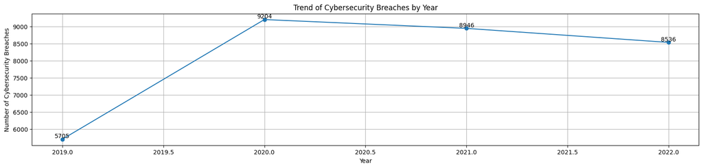

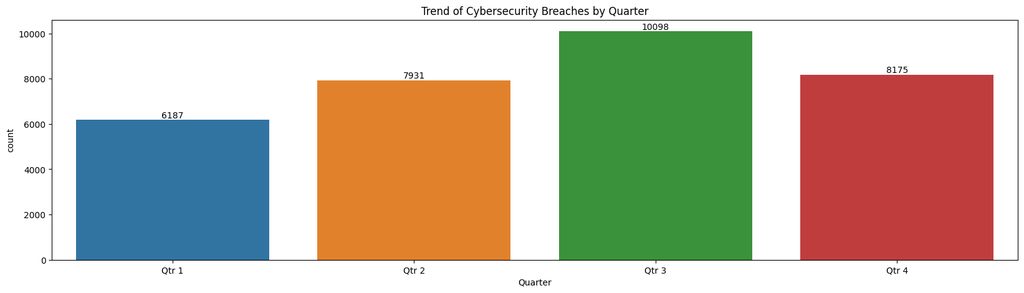

```python
# Calculates yearly counts
year_counts = df2.index.value_counts().sort_index()

## LINE PLOT
# Plots the trend over years
plt.figure(figsize=(20, 4))
plt.plot(year_counts.index, year_counts.values, marker='o')
plt.xlabel('Year')
plt.ylabel('Number of Cybersecurity Breaches')
plt.title('Trend of Cybersecurity Breaches by Year')
plt.grid(True)

# Annotates the data points with their values
for i, count in enumerate(year_counts.values):
    plt.text(year_counts.index[i], count, str(count), ha='center', va='bottom')

plt.show()


## BAR PLOT
# Sorts by Quarter
quarters_order = ['Qtr 1', 'Qtr 2', 'Qtr 3', 'Qtr 4']

# Plots graph
plt.figure(figsize=(20, 5))
plt.title('Trend of Cybersecurity Breaches by Quarter')
ax = sns.countplot(data=df2, x='Quarter', order=quarters_order)

for label in ax.containers:
    ax.bar_label(label)

plt.show()
```

If a further individual analysis is needed, I can plot all the individual quarters per each year.

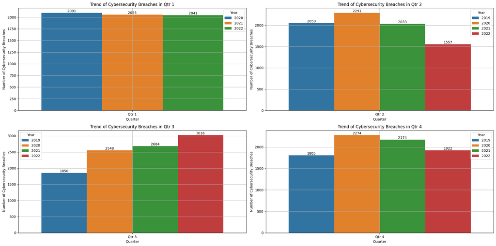

```python
# Array with different Quarters
quarters = ['Qtr 1', 'Qtr 2', 'Qtr 3', 'Qtr 4']

plt.figure(figsize=(20, 10))

# Nested loop to plot 4 bar graph for each quarter
for i, quarter in enumerate(quarters):
    quarter_data = df2.loc[df2['Quarter'] == quarter]

    # Plots in a 2x2 grid
    ax = plt.subplot(2, 2, i+1)
    sns.countplot(data=quarter_data, x='Quarter', hue=quarter_data.index, ax=ax)
    plt.title(f'Trend of Cybersecurity Breaches in {quarter}')
    for label in ax.containers:
        ax.bar_label(label)
    plt.xlabel('Quarter')
    plt.ylabel('Number of Cybersecurity Breaches')
    plt.legend(title='Year')
    plt.grid(True)

# Adjusts the space between plots
plt.tight_layout()
plt.show()
```

What is particularly interesting in this data representation is the progressive uptrend of Q3 over the years. There could be several factors contributing to the observed increase in cyberattacks during Q3:

- Q3 often coincides with increased business activities, such as the back-to-school season, major holidays, or the preparation for year-end financial reporting. Cybercriminals may take advantage of this busy period when organisations and individuals are more focused on their operations and may have relaxed security measures in place.
- Q3 is a critical time for many industries, including retail, finance, and e-commerce. Cybercriminals may target these sectors during peak sales periods or when financial transactions are high, aiming to exploit vulnerabilities and gain access to sensitive customer information or financial data.
- Q3 can be a challenging time for organisations, as they may be dealing with staffing changes, budget adjustments, or the introduction of new projects and systems. These transitional periods can lead to temporary vulnerabilities in an organisation's cybersecurity defences, making them more susceptible to cyberattacks.

### 2. Which year and quarter experienced the highest number of cybersecurity breaches?

To answer these questions I will isolate the column 'Year' and count the number of incidents per year and display the first row of the data.

```python
year = df2.index.value_counts().reset_index()
year.columns = ['Year', 'Number of Breaches']

# Requests the year with highest number of breaches
top_year = year.sort_values('Number of Breaches', ascending=False).head(1)
print(top_year)
```

```
   Year  Number of Breaches
0  2020                9204
```

As the same is required for the 'Quarter' I will changes make changes to the above code.

```python
quarter = df2['Quarter'].value_counts().reset_index()
quarter.columns = ['Quarter', 'Number of Breaches']

# Requests the quarter with highest number of breaches
top_quarters = quarter.sort_values('Number of Breaches', ascending=False).head(1)
print(top_quarters)
```

```
  Quarter  Number of Breaches
0   Qtr 3               10098
```

Based on the provided data, the year 2020 and the quarter "Qtr 3" both experienced the highest number of cybersecurity breaches. The count for the year 2020 is 9204, and the count for the quarter "Qtr 3" is 10098.

### 3. What are the different types of data Types and data subject types affected by the breaches?

'Data type' is a category of data that has been compromised by the breach. Similliary, 'Data subject type' is a type of person affected by the breach. Therefore, to answer this question I can isolate the items from the column 'Data Subject Type' and print the unique values from that output.

```python
# Filters all the unique values from the column 'Data Subject Type' and prints it
dataSubjectType = df2['Data Subject Type'].unique()
print(dataSubjectType)
```

```
['Customers or prospective customers' 'Children' 'Employees' 'Users'
 'Students' 'Unknown' 'Patients' 'Vulnerable adults' 'Subscribers']
```

Altough, if I require more information, as how many times that a certain Data type is breached, I can do the folllowing:

```python
# Filters all the unique values from the column 'Data Type' and prints it
data_types = df2['Data Type'].value_counts().reset_index()
data_types.columns = ['Data Type', 'Number of Breaches']

display(data_types)
```

|  | Data Type | Number of Breaches |
| --- | --- | --- |
| 0 | Basic personal identifiers | 10749 |
| 1 | Economic and financial data | 4256 |
| 2 | Identification data | 3732 |
| 3 | Official documents | 2716 |
| 4 | Health data | 2655 |
| 5 | Unknown | 1941 |
| 6 | Location data | 1573 |
| 7 | Data revealing racial or ethnic origin | 1508 |
| 8 | Criminal convictions or offences | 829 |
| 9 | Religious or philosophical beliefs | 686 |
| 10 | Sexual orientation data | 540 |
| 11 | Genetic or biometric data | 305 |
| 12 | Trade union membership | 294 |
| 13 | Gender Reassignment Data | 235 |
| 14 | Sex life data | 208 |
| 15 | Political opinions | 164 |

Data breaches have impacted various types of data subjects, including basic personal identifiers, economic and financial data, health data, and identification data.

For the cloudmask website (Accessed 2023), these types of information attract the attention of third parties for whom the data has value. Personal, financial, and health information can be sold and used for marketing, fraud, and identity theft. Intellectual property can be sold and used to develop products and services similar to those of your business. Competitive information can be sold and used by your competitors to block your plans, and leaked legal information may damage your legal position. Data on IT security is a valuable target in itself because it lets unauthorised parties gain access to all the other types of information on your system.

### 4. Which specific data types are most commonly compromised in the breaches?

I will use a bar graph to display the most commonly compromised data types:

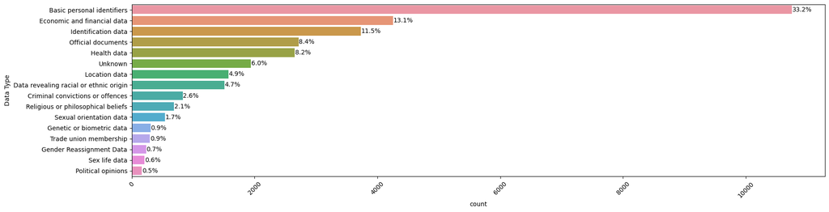

```python
# Plots the graph
plt.figure(figsize=(20, 5))
ax = sns.countplot(data=df2
                    , y='Data Type'
                    , order=df2['Data Type'].value_counts().sort_values(ascending=False).index)

# Total number of data points
total = len(df2)

# Displays labels
for p in ax.patches:
    percentage = '{:.1f}%'.format(100 * p.get_width() / total)  # Calculate the percentage
    x = p.get_width() + 5  # Adjust the x-coordinate for the annotation
    y = p.get_y() + p.get_height() / 2  # Calculate the y-coordinate for the annotation
    ax.annotate(percentage, (x, y), ha='left', va='center')

plt.xticks(rotation=45)
plt.show()
```

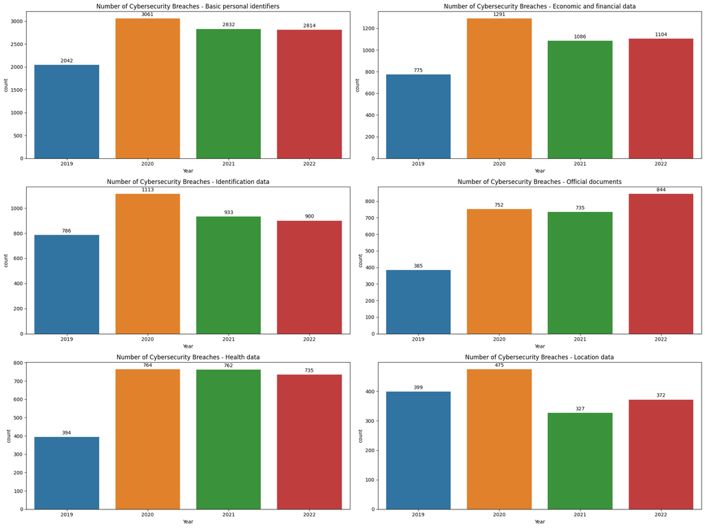

```python
# Stores the data types
data_types = ['Basic personal identifiers', 'Economic and financial data', 'Identification data', 'Official documents', 'Health data', 'Location data']
fig, axes = plt.subplots(nrows=3, ncols=2, figsize=(20, 15))

# Nested loop to display the plots in a grid
for i, data_type in enumerate(data_types):
    quarter_2020 = df2.loc[df2['Data Type'] == data_type]
    ax = axes[i//2, i%2]
    sns.countplot(data=quarter_2020, x=quarter_2020.index, ax=ax)
    ax.set_title(f'Number of Cybersecurity Breaches - {data_type}')

    # Add counting labels
    for container in ax.containers:
        for bar in container:
            height = bar.get_height()
            ax.annotate(f'{int(height)}', xy=(bar.get_x() + bar.get_width() / 2, height),
                        xytext=(0, 3), textcoords='offset points',
                        ha='center', va='bottom')

plt.tight_layout()
plt.show()
```

### 5. What decisions were typically taken in response to the breaches?

'Decisions taken' are actions determined by the ICO, needed to respond to the breach. I can produce a table, using 'Decisions taken' column and answer this question:

```python
# Displays on a table the number of items grouped by each 'Decision Taken'
data_types = df2['Decision Taken'].value_counts().reset_index()
data_types.columns = ['Decision Taken', 'Number of Breaches']
#
#  Displays the tabel
display(data_types)
```

|  | Decision Taken | Number of Breaches |
| --- | --- | --- |
| 0 | Investigation Pursued | 14946 |
| 1 | No Further Action | 12470 |
| 2 | Informal Action Taken | 4859 |
| 3 | Not Yet Assigned | 116 |

The majority of the breaches are investigated, however, not much far than this decision is the 'No further action'. I can use a pie graph to represent this data in more detail:

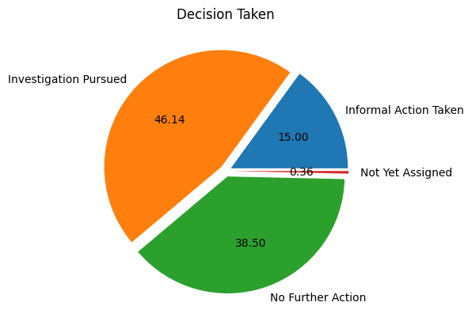

```python
# Sorts the unique values in the 'Decision Taken' column
decision_Taken = sorted(list(set(df['Decision Taken'])))

# Counts the occurrences of each unique 'Decision Taken' value
counts = [df2.loc[df2['Decision Taken'] == name].size for name in decision_Taken]

# Sets the explosion effect for the pie chart
explode = (0.05, 0.05, 0.05, 0.05)

# Sets the title for the pie chart
plt.title('Decision Taken')

# Create a pie chart with the provided data
plt.pie(counts,
        explode=explode,  # Apply the explosion effect
        labels=decision_Taken,  # Set the labels for each slice
        autopct='%1.2f')  # Display the percentage of each slice

# Displays the pie chart
plt.show()
```

According to the data in this dataframe, 46.14% of the incidents were treated seriously and subject to investigation. In 15% of the cases, informal actions were taken, while in 38.5% of the incidents, no further actions were assumed to be necessary. At the time this dataframe was collected, approximately 0.36% of the incidents were not assigned any specific actions.

To obtain a greater understanding of the reasons behind the decisions to not take further action or to decide on informal actions, I will conduct a comprehensive investigation further down in this project. This analysis aims to unveil the factors or circumstances that influenced these decisions and determine if there are any patterns or trends that can provide insights into the incident management process.

### 6. What are the most common types of cybersecurity incidents recorded?

Incident type in this data set is how the breach occured and whether it was a deliberate act that led to the breach or an error. I will be able to demonstrate and answer using the following table:

```python
# Counts the occurrences of each unique incident type in the 'Incident Type' column
incident_types = df2['Incident Type'].value_counts().reset_index()

# Assigns column names 'Incident Type' and 'Count' to the columns of the incident_types
incident_types.columns = ['Incident Type', 'Number of Breaches']
display(incident_types)
```

|  | Incident Type | Number of Breaches |
| --- | --- | --- |
| 0 | Phishing | 12556 |
| 1 | Ransomware | 10493 |
| 2 | Unauthorised access | 3580 |
| 3 | Other cyber incident | 3483 |
| 4 | Malware | 1461 |
| 5 | Brute Force | 724 |
| 6 | Denial of service | 94 |

Based on the dataset results, the most common types of cybersecurity incidents recorded include Phishing, Ransomware, unauthorised access, and Other cyber incidents. Phishing accounted for the highest number of incidents, with 12,556 recorded cases. Phishing attacks involve deceptive tactics to trick individuals into revealing sensitive information or performing malicious actions. This confirms the overall trend around the world. Alkhalil et al. (2021) denote that, at present, phishing is considered one of the most frequent examples of fraud activity on the Internet. Phishing attacks can lead to severe losses for their victims, including sensitive information, identity theft, company secrets, and government secrets.

Ransomware was the second-most common type of incident, with 10,493 cases. Ransomware attacks involve encrypting a victim's data and demanding a ransom for its release. Ransomware attacks have gained significant prominence in recent years due to their destructive nature and widespread impact. The main reasons are presumed to be its high profitability and feasibility of execution. According to a 2016 report (PhishMe, 2016), 93% of all phishing emails contained encryption ransomware.

Unauthorised access was another prominent type, with 3,580 incidents recorded. This refers to unauthorised individuals gaining access to computer systems, networks, or data without proper authorization. Such incidents highlight the importance of strong access controls and security measures.

It's worth noting that these findings are based on the provided dataset, and there may be other types of cybersecurity incidents not captured in the data.

### 7. How many data subjects, on average, were affected by each breach?

To answer this question I will first display the categories within 'No. Data Subjects Affected' alongside with the number of breaches.

```python
# Counts the occurrences of each unique incident type in the 'No. Data Subjects Affected' column
affected = df2['No. Data Subjects Affected'].value_counts().reset_index()

# Assigns column names 'No. Data Subjects Affected' and 'Count'
affected.columns = ['No. Data Subjects Affected', 'Number of Breaches']
display(affected)
```

|  | No. Data Subjects Affected | Number of Breaches |
| --- | --- | --- |
| 0 | Unknown | 13016 |
| 1 | 100 to 1k | 6250 |
| 2 | 1k to 10k | 5088 |
| 3 | 10 to 99 | 3306 |
| 4 | 1 to 9 | 2283 |
| 5 | 10k to 100k | 1547 |
| 6 | 100k and above | 901 |

This dataset has a category of 'Unknow' number of data subjects affected. as unknown cannot be measured, this will require further data cleaning or in this case remove this rows. In certain cases, determining the precise number of affected subjects can be challenging. This could occur when the incident involves complex systems, multiple interconnected networks, or third-party dependencies. The extent of the impact may not be immediately apparent, leading to uncertainties in quantifying the number of affected people and report it. However, I can see that the most affected groups are 100.000 to 1000, the third-smallest group. Now I will calculate the average of people affected using the following code:

```python
# Measures each of the affected groups and store it in a variable
Subjects_100_to_1k =  len(df2.loc[(df2['No. Data Subjects Affected'] == '100 to 1k')])
Subjects_1k_to_10k = len(df2.loc[(df2['No. Data Subjects Affected'] == '1k to 10k')])
Subjects_10_to_99 = len(df2.loc[(df2['No. Data Subjects Affected'] == '10 to 99')])
Subjects_1_to_9 = len(df2.loc[(df2['No. Data Subjects Affected'] == '1 to 9')])
Subjects_10_to_100k = len(df2.loc[(df2['No. Data Subjects Affected'] == '10k to 100k')])
Subjects_unknown = len(df2.loc[(df2['No. Data Subjects Affected'] == 'Unknown')])
Subjects_100k_and_above = len(df2.loc[(df2['No. Data Subjects Affected'] == '100k and above')])

# Adds the data into an array stored in the variable data
data = {
    'No. Data Subjects Affected': ['Unknown', '100 to 1k', '1k to 10k', '10 to 99', '1 to 9', '10k to 100k', '100k and above'],
    'Count': [Subjects_unknown, Subjects_100_to_1k, Subjects_1k_to_10k, Subjects_10_to_99, Subjects_1_to_9, Subjects_10_to_100k, Subjects_100k_and_above]
}

df = pd.DataFrame(data)

# Calculates the midpoint for each range
midpoints = {
    '100 to 1k': (1000 - 100) / 2,
    '1k to 10k': (10000 - 1000) / 2,
    '10 to 99': (99 - 10) / 2,
    '1 to 9': (9 - 1) / 2,
    '10k to 100k': (100000 - 10000) / 2,
}

# Multiplies count by midpoint and sum the values so we can exclude (~) them from the calculation
sum_values = sum(df.loc[~df['No. Data Subjects Affected'].isin(['Unknown', '100k and above']), 'Count']
                 * df.loc[~df['No. Data Subjects Affected'].isin(['Unknown', '100k and above']), 'No. Data Subjects Affected'].map(midpoints))

# Sums the counts
sum_counts = df.loc[~df['No. Data Subjects Affected'].isin(['Unknown', '100k and above']), 'Count'].sum()

# Calculates the average
average = sum_values / sum_counts

# Removed decimal places
average = round(average, 0)

# Prints the result
print(f"The average number of data subjects affected is: {average} people")
```

```
The average number of data subjects affected is: 5168.0 people
```

### 8. What are the top 5 sectors or industries are most frequently targeted by cybersecurity breaches?

Once again, using a table I will be able to present the data and the results to answer this question:

```python
# Counts the occurrences of each unique incident type in the 'Sector' column
sector = df2['Sector'].value_counts().reset_index()

##  Assigns column names 'Sector' and 'Count'
sector.columns = ['Sector', 'Number of Breaches']

# Sorts by descending order
top_5_sectors = sector.sort_values('Number of Breaches', ascending=False).head(5)

# Display table
display(top_5_sectors)
```

|  | Sector | Number of Breaches |
| --- | --- | --- |
| 0 | Education and childcare | 6527 |
| 1 | Retail and manufacture | 5229 |
| 2 | Finance, insurance and credit | 3793 |
| 3 | General business | 2723 |
| 4 | Legal | 2290 |

The top 5 sectors for cyberattacks, Education and childcare, Retail and manufacture, Finance, insurance and credit, General business, and Legal, are targeted for various reasons. Education and childcare institutions hold valuable personal information, making them attractive targets for identity theft and financial fraud. The retail and manufacturing sectors are targeted due to the vast amount of customer data they process, which can be exploited for financial gains through unauthorised use or fraud. The finance, insurance, and credit sectors are prime targets for cyberattacks due to the sensitive financial information they handle. General business entities are targeted for vulnerabilities in their systems and to steal sensitive information. Law firms and legal institutions are targeted for their access to confidential client data, which can be exploited for corporate espionage or financial gain. Overall, the motives behind targeting these sectors vary, but they often involve the potential for financial gain, valuable information, or system disruption.

### 9. What is the average time taken to report a breach after its occurrence?

'Time taken to report' means how long, in hours it took an organisation to report a breach after it had been discovered. Therefore, to answer this question, I will start by displaying the different categories within the 'Time taken to report' and respective number of breaches.

```python
# Counts the occurrences of each unique incident type in the 'Time Taken to Report' column
sector = df2['Time Taken to Report'].value_counts().reset_index()

##  Assigns column names 'Time Taken to Report' and 'Count'
sector.columns = ['Time Taken to Report', 'Number of Breaches']

# Display table
display(sector)
```

|  | Time Taken to Report | Number of Breaches |
| --- | --- | --- |
| 0 | 24 hours to 72 hours | 14360 |
| 1 | 72 hours to 1 week | 7412 |
| 2 | Less than 24 hours | 5357 |
| 3 | More than 1 week | 5262 |

```python
# Measures each of the time taken to report groups and store it in a variable
Subjects_24h_to_72h =  len(df2.loc[(df2['Time Taken to Report'] == '24 hours to 72 hours')])
Subjects_72h_to_1w =  len(df2.loc[(df2['Time Taken to Report'] == '72 hours to 1 week')])
Subjects_24h =  len(df2.loc[(df2['Time Taken to Report'] == 'Less than 24 hours')])

# Adds the data into an array stored in the variable data
data = {
    'Time Taken to Report': ['24 hours to 72 hours', '72 hours to 1 week', 'Less than 24 hours'],
    'Count': [Subjects_24h_to_72h, Subjects_72h_to_1w, Subjects_24h]
}

df = pd.DataFrame(data)

# Assign durations to each time interval
# As we using intervals to measure the time take, I will assume the middle point of that time frame.
time_mapping = {
    '24 hours to 72 hours': (((3*24)-24)/2)+24,  # Assuming 3 days I remove the 24h and find the midle point and we add 24h that is not included
    '72 hours to 1 week': (((7*24) - (3*24))/2),  # Assuming 7 days I remove 3 days and find the midle point
    'Less than 24 hours': (24/2),  # Assuming a full day
}

# Calculate the weighted average time taken to report
average_time = (df['Time Taken to Report'].map(time_mapping) * df['Count']).sum() / df['Count'].sum()

# Rounds to remove the decimal place
average_time = round(average_time, 0)

# Prints the result
print(f"The average time taken to report a breach is: {average_time}h")
```

```
The average time taken to report a breach is: 41.0h
```

According to the ICO (Information Commissioner Officer), by law, companies have to report a personal data breach to the ICO without undue delay (if it meets the threshold for reporting) and within 72 hours. As can be seen by the output, the average time to report a breach is 41 hours, fulfilling the requirement. But there is still a percentage of breaches that fall outside of this time frame.

```python
# Calculate the total count
total_count = sector['Number of Breaches'].sum()

# Add a new column for percentage
sector['Percentage (%)'] = (sector['Number of Breaches'] / total_count) * 100

sector_percentage = round(sector, 1)

# Display the updated DataFrame
display(sector_percentage)
```

|  | Time Taken to Report | Number of Breaches | Percentage (%) |
| --- | --- | --- | --- |
| 0 | 24 hours to 72 hours | 14360 | 44.3 |
| 1 | 72 hours to 1 week | 7412 | 22.9 |
| 2 | Less than 24 hours | 5357 | 16.5 |
| 3 | More than 1 week | 5262 | 16.2 |

### 10. What is the distribution of cybersecurity breach incidents across different sectors?

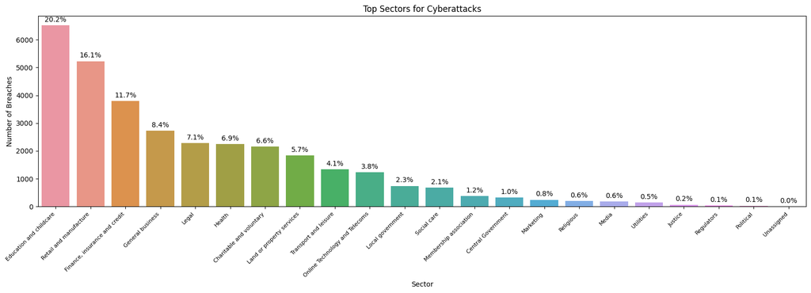

```python
# Resets the index of the DataFrame
df2.reset_index(inplace=True)

plt.figure(figsize=(20, 5))
ax = sns.countplot(data=df2, x='Sector', order=df2['Sector'].value_counts().sort_values(ascending=False).index)

# Adjust x-axis tick labels to display as two lines
ax.set_xticklabels(ax.get_xticklabels(), rotation=45, ha='right', fontsize=8, multialignment='center')

# Calculate the total number of observations
total = len(df2)

# Add percentage labels to the bars
for container in ax.containers:
    for bar in container:
        height = bar.get_height()
        percentage = height / total * 100
        ax.annotate(f'{percentage:.1f}%', xy=(bar.get_x() + bar.get_width() / 2, height),
                    xytext=(0, 3), textcoords='offset points',
                    ha='center', va='bottom')

plt.ylabel('Number of Breaches')
plt.title('Top Sectors for Cyberattacks')

plt.show()
```

As previously seen, 'Education and childcare' take 20% of the attacks, followed by 'Retail and manufacture' (16.1%), 'Finance, insurance and credit' (11.7%), 'General business' (8.4%).

### Bivariable analysis

I will continue to visualize Bivariates, to demonstrate the relationship between the variables in the information.

I will use the following questions to guide my research of the data set.

1. Is there a relationship between the 'Data Subject Type' and the 'Decision Taken'?
2. Are certain 'Data Types' more prevalent in specific 'Sectors'?
3. How does the 'No. Data Subjects Affected' differ based on the 'Incident Type'?
4. Is there any association between the 'Decision Taken' and the 'Time Taken to Report'?
5. Does the 'No. Data Subjects Affected' vary across different 'Data Types'?
6. How does the 'Decision Taken' differ based on the 'Sector'?
7. Is there a relationship between the 'Data Subject Type' and the 'Time Taken to Report'?
8. Are there any patterns in the 'Incident Type' based on the 'Quarter'?

[figure not shown]

```python
# Filters the DataFrame based on specific 'Decision Taken' values
decision_take = df2[(df2['Decision Taken'] == 'No Further Action') | (df2['Decision Taken'] == 'Investigation Pursued') | (df2['Decision Taken'] == 'Informal Action Taken')]

# Set the size of the figure for the plot
plt.figure(figsize=(20, 5))

# Creates a countplot using seaborn library
ax = sns.countplot(data=decision_take, x='Incident Type', hue='Decision Taken')

# Adds labels to the bars of the countplot
for label in ax.containers:
    ax.bar_label(label)

# Sets the title of the plot
plt.title('Relationship between the Data Subject Type and the Decision Taken')

# Displays the plot
plt.show()
```

The data visualisation reveals two notable observations. Firstly, phishing attacks typically do not lead to subsequent actions. Phishing attacks primarily rely on deceiving individuals into divulging sensitive information or performing specific actions. If a phishing email is identified and deleted before any sensitive data is compromised, affected individuals may perceive the incident as resolved without pursuing further investigation or action. The significance of training and education becomes evident, and that is evident in the graph showing that phishing required more informal action than any other data subject. Providing individuals with proper training and education plays a crucial role in familiarising them with common indicators of phishing attempts, such as suspicious email addresses, grammatical errors, urgent requests for personal information, or unexpected attachments or links. By raising awareness and equipping individuals with knowledge on recognising and responding to phishing attacks, the likelihood of falling victim to such attacks can be significantly reduced. (Jensen et al. 2017)

Second, Ransomware is taken seriously and formally investigated. Ransomware attacks are capable of encrypting and blocking access to an organization's data, requesting some kind of payment in exchange for restoring access to the data. This results in disruption to operations, potential compromise of sensitive information, and financial and reputational losses. Given the possible operational, economic, and security implications, these attacks are considered high-priotirty incidents and require formal investigation to mitigate the impact, identify the responsible parties, and prevent future attacks. (Oz et al., 2022)

### 2. Are certain 'Data Types' more prevalent in specific 'Sectors'?

To analyse this data, and be able to answer this question, I will use a cross table with a background gradient:

```python
# Creates a cross-tabulation table
cross_table = pd.crosstab(df2['Data Type'], df2['Sector'])

# Applies styling to the table
styled_table = cross_table.style.background_gradient(axis=0, cmap='Greens')

# Renders the styled table
styled_table
```

| Sector Data Type | Central Government | Charitable and voluntary | Education and childcare | Finance, insurance and credit | General business | Health | Justice | Land or property services | Legal | Local government | Marketing | Media | Membership association | Online Technology and Telecoms | Political | Regulators | Religious | Retail and manufacture | Social care | Transport and leisure | Unassigned | Utilities |
| --- | --- | --- | --- | --- | --- | --- | --- | --- | --- | --- | --- | --- | --- | --- | --- | --- | --- | --- | --- | --- | --- | --- |
| Basic personal identifiers | 71 | 726 | 1582 | 1288 | 1063 | 666 | 15 | 630 | 784 | 208 | 67 | 66 | 171 | 532 | 7 | 11 | 61 | 2015 | 191 | 531 | 1 | 63 |
| Criminal convictions or offences | 19 | 57 | 235 | 150 | 37 | 35 | 9 | 49 | 71 | 42 | 7 | 2 | 1 | 16 | 0 | 0 | 9 | 53 | 19 | 17 | 0 | 1 |
| Data revealing racial or ethnic origin | 30 | 141 | 600 | 56 | 73 | 130 | 5 | 76 | 80 | 45 | 10 | 7 | 20 | 32 | 3 | 2 | 0 | 128 | 50 | 18 | 0 | 2 |
| Economic and financial data | 15 | 258 | 633 | 682 | 394 | 148 | 1 | 283 | 349 | 54 | 41 | 34 | 40 | 149 | 3 | 3 | 23 | 840 | 77 | 205 | 0 | 24 |
| Gender Reassignment Data | 9 | 23 | 115 | 5 | 10 | 30 | 1 | 10 | 9 | 6 | 0 | 0 | 3 | 7 | 0 | 0 | 0 | 5 | 0 | 2 | 0 | 0 |
| Genetic or biometric data | 6 | 11 | 143 | 12 | 12 | 44 | 6 | 8 | 24 | 5 | 3 | 0 | 0 | 0 | 0 | 0 | 0 | 21 | 3 | 7 | 0 | 0 |
| Health data | 35 | 216 | 741 | 209 | 144 | 417 | 4 | 120 | 136 | 90 | 4 | 8 | 16 | 54 | 3 | 2 | 19 | 263 | 96 | 69 | 0 | 9 |
| Identification data | 33 | 220 | 771 | 400 | 342 | 178 | 4 | 178 | 166 | 78 | 29 | 38 | 44 | 240 | 0 | 3 | 10 | 764 | 54 | 167 | 0 | 13 |
| Location data | 21 | 81 | 265 | 197 | 164 | 107 | 9 | 120 | 85 | 36 | 18 | 7 | 30 | 49 | 3 | 0 | 6 | 252 | 44 | 72 | 0 | 7 |
| Official documents | 22 | 147 | 418 | 504 | 216 | 109 | 3 | 179 | 303 | 25 | 28 | 8 | 15 | 67 | 0 | 2 | 8 | 451 | 58 | 137 | 0 | 16 |
| Political opinions | 5 | 18 | 53 | 5 | 5 | 10 | 0 | 8 | 20 | 9 | 8 | 0 | 2 | 3 | 7 | 0 | 5 | 6 | 0 | 0 | 0 | 0 |
| Religious or philosophical beliefs | 22 | 74 | 313 | 19 | 32 | 33 | 3 | 20 | 36 | 31 | 9 | 0 | 8 | 7 | 0 | 2 | 27 | 27 | 15 | 8 | 0 | 0 |
| Sex life data | 8 | 11 | 66 | 7 | 10 | 47 | 2 | 5 | 24 | 11 | 0 | 0 | 0 | 0 | 0 | 0 | 6 | 3 | 8 | 0 | 0 | 0 |
| Sexual orientation data | 12 | 53 | 205 | 14 | 27 | 67 | 0 | 30 | 26 | 21 | 9 | 2 | 0 | 4 | 3 | 2 | 12 | 21 | 27 | 4 | 0 | 1 |
| Trade union membership | 2 | 16 | 116 | 3 | 12 | 5 | 0 | 14 | 14 | 23 | 6 | 3 | 5 | 3 | 3 | 2 | 0 | 48 | 10 | 8 | 0 | 1 |
| Unknown | 9 | 102 | 271 | 242 | 182 | 215 | 5 | 101 | 163 | 59 | 5 | 7 | 24 | 76 | 0 | 5 | 8 | 332 | 31 | 93 | 0 | 11 |

Using this gradient table and after carefully analysing it, Basic personal identifiers seem to be the most attractive data for cyber criminals. However, such an amount of data would be better analysed using data visualisation techniques and plotted by individual sectors.

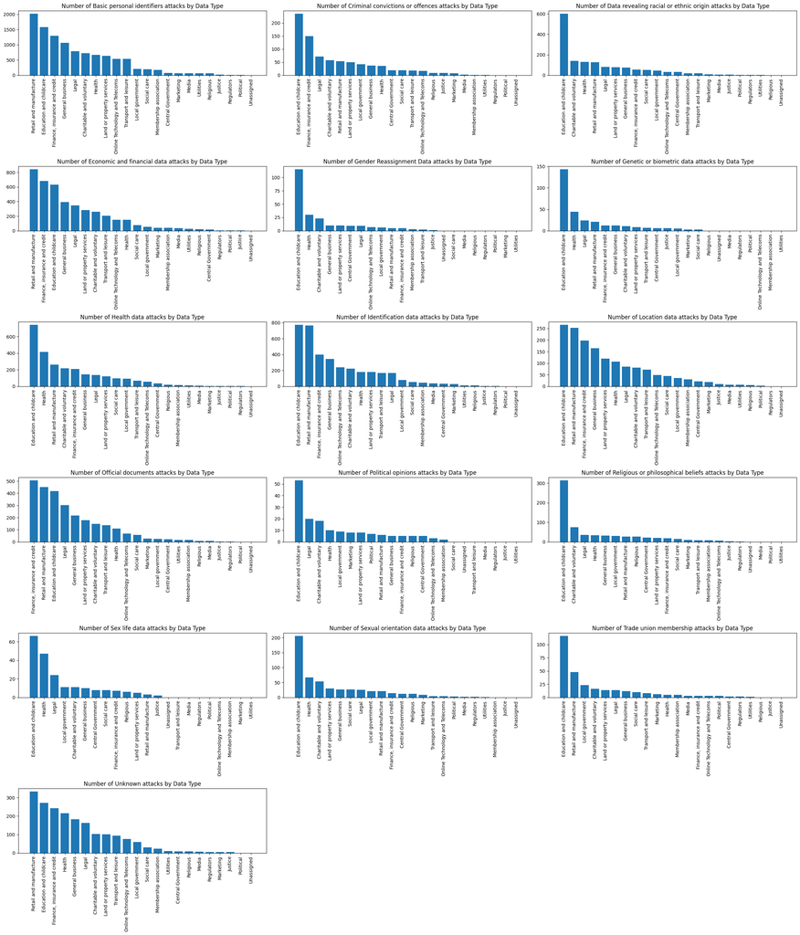

```python
# Creates a cross-tabulation table
cross_table = pd.crosstab(df2['Sector'], df2['Data Type'])

# Gets the number of rows and columns for the subplots
num_rows = 8
num_cols = 3

# Creates a figure and subplots
fig, axes = plt.subplots(num_rows, num_cols, figsize=(24, 35))

# Flattens the axes array for easier iteration
axes = axes.flatten()

# Iterates over the columns and plot a graph for each column
for i, column in enumerate(cross_table.columns):
    ax = axes[i]

    # Gets the counts for the current column and sectors
    counts = cross_table[column]

    # Sorts the counts in descending order and get the corresponding sectors
    sorted_counts = counts.sort_values(ascending=False)
    sorted_sectors = sorted_counts.index

    # Plots the graph with the sectors ordered by counts
    ax.bar(sorted_sectors, sorted_counts)
    ax.set_title(f'Number of {column} attacks by Data Type')
    ax.tick_params(axis='x', rotation=90)

# Removes any unused subplots
for j in range(i+1, num_rows*num_cols):
    fig.delaxes(axes[j])

# Adjusts the spacing between subplots
fig.tight_layout()

# Shows the figure
plt.show()
```

This is great to analyse individually the attacks by sector, however, to have a full picture, I can plot all the sectors in the same graph and analyse them.

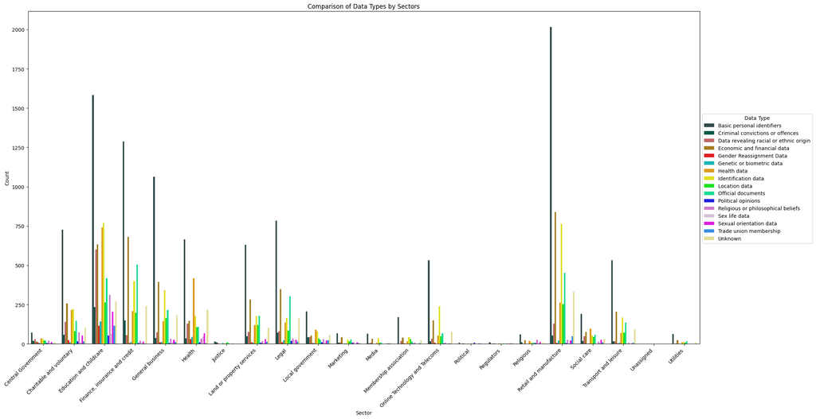

```python
# Defines a custom color palette with 16 distinct colors
custom_palette = ['#2f4f4f', '#006450', '#cd5c5c', '#b8860b', '#ff0000', '#00ced1', '#ffa500', '#ffff00',
                  '#00ff00', '#00fa9a', '#0000ff', '#da70d6', '#d8bfd8', '#ff00ff', '#1e90ff', '#f0e68c']

# Groups the data by 'Data Type' and 'Sector' and calculate the count
grouped_data = df2.groupby(['Sector', 'Data Type']).size().reset_index(name='Count')


# Plots the grouped bar chart with the custom color palette
plt.figure(figsize=(24, 12))
sns.barplot(data=grouped_data, x='Sector', y='Count', hue='Data Type', palette=custom_palette)
plt.title('Comparison of Data Types by Sectors')
plt.xlabel('Sector')
plt.ylabel('Count')
plt.xticks(rotation=45, ha='right')
plt.legend(title='Data Type', bbox_to_anchor=(1, 0.7))
plt.show()
```

This highlights the significance of protecting individuals' personal information, as it is a prime target for cybercriminals. Additionally, the sectors mentioned face substantial challenges in safeguarding their systems and data, making them more vulnerable to cyberattacks.

### 3. How does the 'No. Data Subjects Affected' differ based on the 'Incident Type'?

Once again, I will use a bacrkground gradient table to highlith the highest values in the table:

```python
# Creates a cross-tabulation table with totals
cross_table = pd.crosstab(df2['No. Data Subjects Affected'], df2['Incident Type'])

# Applies styling to highlight cells with higher numbers in each column
styled_table = cross_table.style.background_gradient(axis=0, cmap='Greens')

# Renders the styled table
styled_table
```

| Incident Type No. Data Subjects Affected | Brute Force | Denial of service | Malware | Other cyber incident | Phishing | Ransomware | Unauthorised access |
| --- | --- | --- | --- | --- | --- | --- | --- |
| 1 to 9 | 64 | 9 | 127 | 316 | 1134 | 331 | 302 |
| 10 to 99 | 82 | 5 | 126 | 349 | 1489 | 749 | 506 |
| 100 to 1k | 152 | 5 | 242 | 548 | 3062 | 1735 | 506 |
| 100k and above | 29 | 34 | 62 | 111 | 48 | 479 | 138 |
| 10k to 100k | 42 | 1 | 67 | 264 | 168 | 801 | 204 |
| 1k to 10k | 184 | 9 | 138 | 446 | 1655 | 2150 | 506 |
| Unknown | 171 | 31 | 699 | 1449 | 5000 | 4248 | 1418 |

```python
# Defines the desired order for the 'No. Data Subjects Affected' categories
data_subject_order = ['1 to 9', '10 to 99', '100 to 1k', '1k to 10k', '10k to 100k', '100k and above']

# Excludes a specific column category
exclude_category = 'Unknown'
df_filtered = df2[df2['No. Data Subjects Affected'] != exclude_category]

# Creates the cross-tabulation table
cross_table = pd.crosstab(df_filtered['No. Data Subjects Affected'], df_filtered['Incident Type'])

# Reorders the rows based on 'No. Data Subjects Affected'
cross_table = cross_table.reindex(data_subject_order)

# Applies styling to the table
styled_table = cross_table.style.highlight_max(axis=0, color='green')

# Renders the styled table
styled_table
```

| Incident Type No. Data Subjects Affected | Brute Force | Denial of service | Malware | Other cyber incident | Phishing | Ransomware | Unauthorised access |
| --- | --- | --- | --- | --- | --- | --- | --- |
| 1 to 9 | 64 | 9 | 127 | 316 | 1134 | 331 | 302 |
| 10 to 99 | 82 | 5 | 126 | 349 | 1489 | 749 | 506 |
| 100 to 1k | 152 | 5 | 242 | 548 | 3062 | 1735 | 506 |
| 1k to 10k | 184 | 9 | 138 | 446 | 1655 | 2150 | 506 |
| 10k to 100k | 42 | 1 | 67 | 264 | 168 | 801 | 204 |
| 100k and above | 29 | 34 | 62 | 111 | 48 | 479 | 138 |

- Brute force can affect a fair amount of subjects, especially if you break into a high-ranking security access point;
- Denial of service can be very destructive, affecting a very large number of subjects; however, it is not very common due to its difficulty to implement.
- Malware and unauthorised access tend to be the median events where there are a fair number of attacks compared to affected subjects.
- Finally, phishing and ransomware can have the most attacks affecting numerous subjects, as these two attacks are related in the majority of cases as the attacker gains access and encrypts the data by using phishing techniques to gain access. To provide further detail, I plotted these results in the following graph.

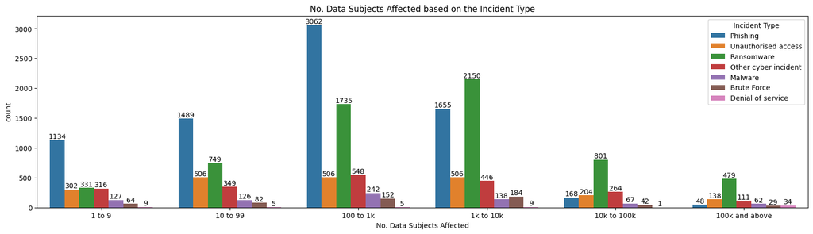

```python
# Defines the desired order for the 'No. Data Subjects Affected' categories
data_subject_order = ['1 to 9', '10 to 99', '100 to 1k', '1k to 10k', '10k to 100k', '100k and above']

# Filters the DataFrame to exclude rows with 'Unknown' in the 'No. Data Subjects Affected' column
decision_take = df2[(df2['No. Data Subjects Affected'] != 'Unknown')]

# Sets the size of the figure for the plot
plt.figure(figsize=(20, 5))

# Create a countplot using seaborn library
ax = sns.countplot(data=decision_take, x='No. Data Subjects Affected', hue='Incident Type', order=data_subject_order)

# Adds labels to the bars of the countplot
for label in ax.containers:
    ax.bar_label(label)

# Sets the title of the plot
plt.title('No. Data Subjects Affected based on the Incident Type')

# Displays the plot
plt.show()
```

### 4. Is there any association between the 'Decision Taken' and the 'Time Taken to Report'?

Usint both columns I will cross merge the data so I can properly analyse it:

```python
# Creates the cross-tabulation table
cross_table = pd.crosstab(df2['Decision Taken'], df2['Time Taken to Report'])

# Applies styling to the table
styled_table = cross_table.style

# Renders the styled table
styled_table
```

| Time Taken to Report Decision Taken | 24 hours to 72 hours | 72 hours to 1 week | Less than 24 hours | More than 1 week |
| --- | --- | --- | --- | --- |
| Informal Action Taken | 2306 | 1111 | 752 | 690 |
| Investigation Pursued | 6633 | 3404 | 2518 | 2391 |
| No Further Action | 5351 | 2878 | 2078 | 2163 |
| Not Yet Assigned | 70 | 19 | 9 | 18 |

And to add more detail and accuracy I will also plot a stacked bar visualisation.

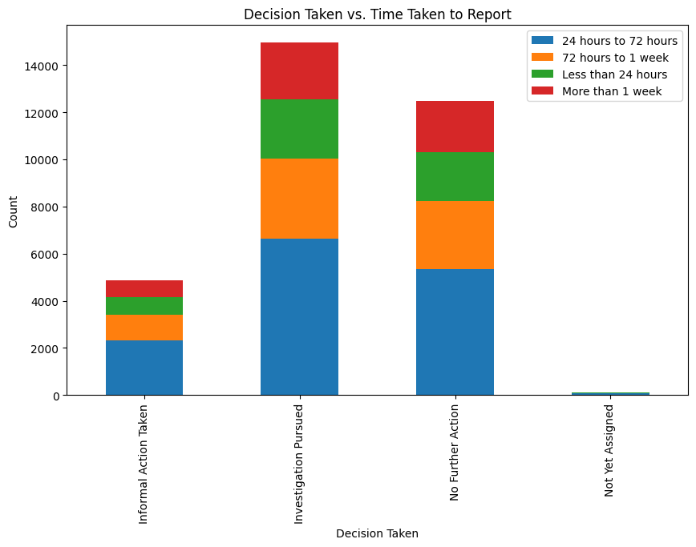

```python
# Creates the cross-tabulation table
cross_table = pd.crosstab(df2['Decision Taken'], df2['Time Taken to Report'])

# Plots the stacked bar chart
cross_table.plot(kind='bar', stacked=True, figsize=(10, 6))

# Sets the labels and title
plt.xlabel('Decision Taken')
plt.ylabel('Count')
plt.title('Decision Taken vs. Time Taken to Report')

# Shows the legend
plt.legend()

# Shows the plot
plt.show()
```

Based on the dataset output, it is perceptible that the most prevalent decisions taken are either "Investigated" or "No further action" taken being the majority of these decisions made within the first 72 hours, with a significant percentage falling within 24 to 72 hours. This suggests that prompt decision-making and timely response are fundamental to facing these incidents effectively.

### 5. Does the 'No. Data Subjects Affected' vary across different 'Data Types'?

To answer this question I will study both columns and print them into a table:

```python
# Defines the desired order for the 'No. Data Subjects Affected' categories
data_subject_order = ['1 to 9', '10 to 99', '100 to 1k', '1k to 10k', '10k to 100k', '100k and above']

# Creates the cross-tabulation table
cross_table = pd.crosstab(df2['No. Data Subjects Affected'], df2['Data Type'])

# Sorts the table by the specified order
cross_table = cross_table.reindex(data_subject_order)

# Applies styling to the table
styled_table = cross_table.style.highlight_max(axis=0, color='red')

# Renders the styled table
styled_table
```

| Data Type No. Data Subjects Affected | Basic personal identifiers | Criminal convictions or offences | Data revealing racial or ethnic origin | Economic and financial data | Gender Reassignment Data | Genetic or biometric data | Health data | Identification data | Location data | Official documents | Political opinions | Religious or philosophical beliefs | Sex life data | Sexual orientation data | Trade union membership | Unknown |
| --- | --- | --- | --- | --- | --- | --- | --- | --- | --- | --- | --- | --- | --- | --- | --- | --- |
| 1 to 9 | 946 | 29 | 58 | 440 | 2 | 12 | 91 | 258 | 105 | 194 | 5 | 30 | 8 | 19 | 9 | 77 |
| 10 to 99 | 1274 | 55 | 120 | 517 | 13 | 17 | 262 | 370 | 177 | 327 | 7 | 28 | 5 | 38 | 10 | 86 |
| 100 to 1k | 2316 | 155 | 267 | 864 | 49 | 29 | 555 | 768 | 315 | 482 | 25 | 130 | 18 | 80 | 51 | 146 |
| 1k to 10k | 1715 | 127 | 279 | 537 | 59 | 82 | 493 | 623 | 287 | 395 | 21 | 143 | 11 | 132 | 64 | 120 |
| 10k to 100k | 482 | 59 | 84 | 189 | 21 | 23 | 136 | 201 | 70 | 135 | 10 | 34 | 17 | 26 | 32 | 28 |
| 100k and above | 286 | 50 | 42 | 78 | 7 | 5 | 75 | 130 | 59 | 49 | 12 | 28 | 9 | 32 | 15 | 24 |

Highlighting the maximum value in each column, it becomes apparent that the majority of the data attacks, in all data types from the dataset, affect between 100 and 10,000 subjects. Also, to be able to visualise with more detail, I will display a bar graph:

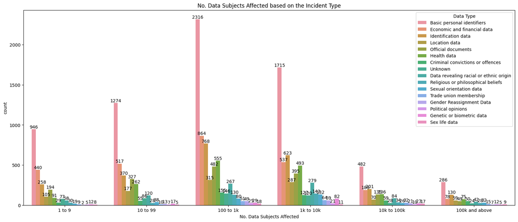

```python
# Defines the desired order for the 'No. Data Subjects Affected' categories
data_subject_order = ['1 to 9', '10 to 99', '100 to 1k', '1k to 10k', '10k to 100k', '100k and above']

# Filters the DataFrame to exclude rows with 'Unknown' in the 'No. Data Subjects Affected' column
decision_take = df2[(df2['No. Data Subjects Affected'] != 'Unknown')]

# Sets the size of the figure for the plot
plt.figure(figsize=(20, 8))

# Creates a countplot using seaborn library
ax = sns.countplot(data=decision_take, x='No. Data Subjects Affected', hue='Data Type', order=data_subject_order)

# Adds labels to the bars of the countplot
for label in ax.containers:
    ax.bar_label(label)

# Sets the title of the plot
plt.title('No. Data Subjects Affected based on the Incident Type')

# Displays the plot
plt.show()
```

Once again, Basic personal identifiers are the most prevalent data type target within any group of affected subjects.

### 6. How does the 'Decision Taken' differ based on the 'Sector'?

```python
# Creates the cross-tabulation table
cross_table = pd.crosstab(df2['Decision Taken'], df2['Sector'])

# Applies styling to the table
styled_table = cross_table.style.highlight_max(axis=0, color='blue')

# Renders the styled table
styled_table
```

| Sector Decision Taken | Central Government | Charitable and voluntary | Education and childcare | Finance, insurance and credit | General business | Health | Justice | Land or property services | Legal | Local government | Marketing | Media | Membership association | Online Technology and Telecoms | Political | Regulators | Religious | Retail and manufacture | Social care | Transport and leisure | Unassigned | Utilities |
| --- | --- | --- | --- | --- | --- | --- | --- | --- | --- | --- | --- | --- | --- | --- | --- | --- | --- | --- | --- | --- | --- | --- |
| Informal Action Taken | 11 | 377 | 916 | 442 | 272 | 343 | 7 | 445 | 435 | 100 | 28 | 30 | 50 | 213 | 1 | 1 | 17 | 888 | 87 | 187 | 1 | 8 |
| Investigation Pursued | 261 | 881 | 3764 | 1520 | 1168 | 774 | 49 | 722 | 982 | 320 | 121 | 78 | 168 | 611 | 21 | 21 | 67 | 2493 | 229 | 616 | 0 | 80 |
| No Further Action | 47 | 896 | 1782 | 1831 | 1283 | 1095 | 11 | 664 | 873 | 322 | 95 | 74 | 161 | 415 | 10 | 12 | 110 | 1827 | 367 | 535 | 0 | 60 |
| Not Yet Assigned | 0 | 0 | 65 | 0 | 0 | 29 | 0 | 0 | 0 | 1 | 0 | 0 | 0 | 0 | 0 | 0 | 0 | 21 | 0 | 0 | 0 | 0 |

Highlighting the maximum value in each column, it becomes apparent that the majority of the data attacks were either pursued or not investigated. Looking in close detail at the sectors that have not been fully investigated: charitable and voluntary', 'Finance, insurance and credit', 'General business', 'Health', 'Local government', 'Religious' and 'Social care, it appears to be a group of institutions with limited resources as a whole impacting the allocation of funds into cybersecurity. Moreover, if the resources are scarce, the professionals may not be able to respond not only to the perceived severity of the attacks but also to the high number of required incidents. These reasons are just potential factors and do not mean that, in the absence of investigation, these sectors do not suffer cyberattacks.

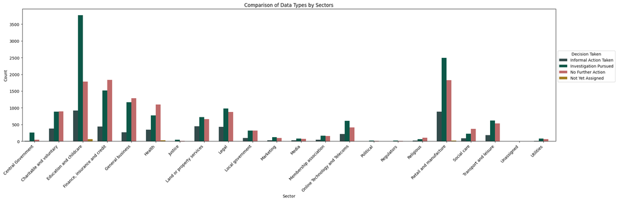

```python
# Groups the data by 'Data Type' and 'Sector' and calculate the count
grouped_data = df2.groupby(['Sector', 'Decision Taken']).size().reset_index(name='Count')

# Plots the grouped bar chart with the custom color palette
plt.figure(figsize=(24, 6))
sns.barplot(data=grouped_data, x='Sector', y='Count', hue='Decision Taken', palette=custom_palette)
plt.title('Comparison of Data Types by Sectors')
plt.xlabel('Sector')
plt.ylabel('Count')
plt.xticks(rotation=45, ha='right')
plt.legend(title='Decision Taken', bbox_to_anchor=(1, 0.7))
plt.show()
```

What is not much visible in the table is that in this dataset are taken very serious attacks on 'education and childcare' and 'retail and manufacture'. Furthermore, it can be confirmed that the above sectors do, indeed, not further investigate most of their attacks.

### 7. Is there a relationship between the 'Data Subject Type' and the 'Time Taken to Report'?

I will print a table cross checking this bother columns, also build a bar visualisation and finally discuss the results:

```python
# Creates the cross-tabulation table
cross_table = pd.crosstab(df2['Data Subject Type'], df2['Time Taken to Report'])

# Applies styling to the table
styled_table = cross_table.style

# Renders the styled table
styled_table
```

| Time Taken to Report Data Subject Type | 24 hours to 72 hours | 72 hours to 1 week | Less than 24 hours | More than 1 week |
| --- | --- | --- | --- | --- |
| Children | 1090 | 449 | 334 | 427 |
| Customers or prospective customers | 4095 | 2397 | 1435 | 1355 |
| Employees | 4714 | 2378 | 1417 | 1579 |
| Patients | 289 | 131 | 149 | 199 |
| Students | 911 | 417 | 317 | 288 |
| Subscribers | 393 | 198 | 130 | 129 |
| Unknown | 746 | 371 | 782 | 376 |
| Users | 1419 | 828 | 518 | 596 |
| Vulnerable adults | 703 | 243 | 275 | 313 |

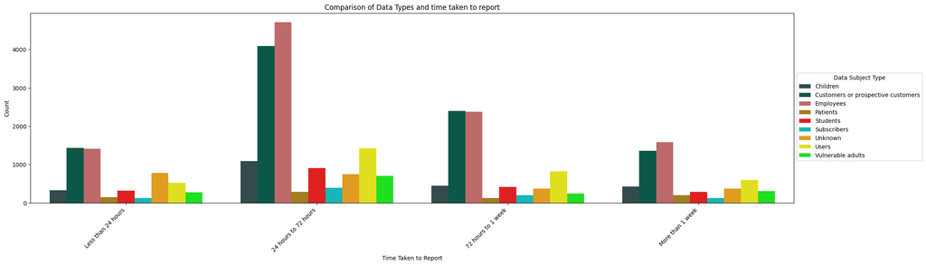

```python
# Defines the desired order for the 'Time Taken' categories
time_taken_labels = ['Less than 24 hours', '24 hours to 72 hours', '72 hours to 1 week', 'More than 1 week']

# Groups the data by 'Data Type' and 'Sector' and calculate the count
grouped_data = df2.groupby(['Data Subject Type', 'Time Taken to Report']).size().reset_index(name='Count')

# Plots the grouped bar chart with the custom color palette
plt.figure(figsize=(24, 6))
sns.barplot(data=grouped_data, x='Time Taken to Report', y='Count', hue='Data Subject Type', palette=custom_palette, order=time_taken_labels)
plt.title('Comparison of Data Types and time taken to report')
plt.xlabel('Time Taken to Report')
plt.ylabel('Count')
plt.xticks(rotation=45, ha='right')
plt.legend(title='Data Subject Type', bbox_to_anchor=(1, 0.7))
plt.show()
```

Customers, employees, and users are the top three data subject types reported because they are the primary targets and sources of valuable information for cyberattackers:

- Customers can have their personal information or payment information stolen.
- Employees have access to their internal systems and sensitive data, making them targets for attackers to obtain unauthorised access and identity theft to gain access to the organization's infrastructure.
- Users, like customers, could be possible targets of phishing campaigns where attackers try to trick users into revealing their credentials or downloading malware.

### 8. Are there any patterns in the 'Incident Type' based on the 'Quarter'?

Using a table comparing 'Incident type' with 'Quarter':

```python
# Creates the cross-tabulation table
cross_table = pd.crosstab(df2['Incident Type'], df2['Quarter'])

# Applies styling to the table
styled_table = cross_table.style

# Renders the styled table
styled_table
```

| Quarter Incident Type | Qtr 1 | Qtr 2 | Qtr 3 | Qtr 4 |
| --- | --- | --- | --- | --- |
| Brute Force | 127 | 256 | 223 | 118 |
| Denial of service | 14 | 4 | 55 | 21 |
| Malware | 284 | 277 | 411 | 489 |
| Other cyber incident | 740 | 737 | 919 | 1087 |
| Phishing | 2470 | 3534 | 3449 | 3103 |
| Ransomware | 1807 | 2084 | 3879 | 2723 |
| Unauthorised access | 745 | 1039 | 1162 | 634 |

It is difficult to answer using this table. I will plot a line-type graph to better understand if there are any patterns.

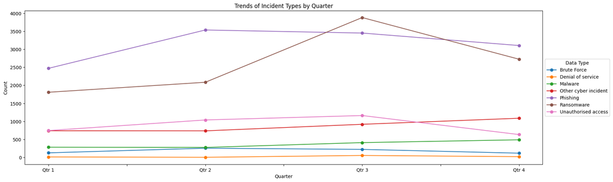

```python
# Creates the cross-tabulation table
cross_table = pd.crosstab(df2['Incident Type'], df2['Quarter'])

# Plots the line chart
fig, ax = plt.subplots(figsize=(20, 6))  # Increase the width to 16
cross_table.T.plot(marker='o', ax=ax)

# Customizes the plot
plt.title('Trends of Incident Types by Quarter')
plt.xlabel('Quarter')
plt.ylabel('Count')
plt.xticks(rotation=0)
plt.legend(title='Incident Type')
plt.legend(title='Data Type', bbox_to_anchor=(1, 0.7))
plt.show()
```

# Webscraping - Pwned Web Site Accounts Breach

## Data retrieval

Have I Been Pwned?--have i been pwned?" is a website that allows Internet users to check whether their personal data has been compromised by data breaches. The service collects and analyzes hundreds of database dumps and pastes containing information about billions of leaked accounts, and allows users to search for their own information by entering their username or email address. Users can also sign up to be notified if their email address appears in future dumps. The site has been widely touted as a valuable resource for Internet users wishing to protect their own security and privacy [Wikipedia](https://www.google.com/url?q=https://en.wikipedia.org/wiki/Have_I_Been_Pwned%253F&sa=D&source=editors&ust=1688215647635072&usg=AOvVaw36yTYhpY1vMpO7WVXIvtgB).

On Pwned website platform, the data is displayed in a tabular format, organised into columns that represent the different attributes of the breached websites. To retrieve this data, I will utilise web scraping techniques involving extracting the data by parsing the HTML structure of the Web page. Using libraries, I will identify the classes and attributes containing the data that need to be extracted. The data will then be saved into a CSV file type, cleaned, and preprocessed by converting data types to remove missing values so that it can be properly analysed.

I start by requesting the data from the Pwned webpage and use the containers to separate the data by their location in the different sections of the HTML. Once the data is collected, it is merged into a table for better analysis.

```python
# Sends a GET request to the website
response = requests.get('https://haveibeenpwned.com/PwnedWebsites')

# Parses the HTML content using BeautifulSoup
soup = BeautifulSoup(response.content, 'html.parser')

# Finds the divs containing the website data
containers = soup.find_all('div', {'class': 'row'})

# Extracts the data from each container
data = []
for container in containers:
    website_name = container.find('h3')
    if website_name is not None:
        website_name = website_name.text.strip()
    else:
        website_name = "N/A"

    breach_date_tag = container.find('strong', string='Breach date:')
    if breach_date_tag is not None:
        breach_date = breach_date_tag.next_sibling.strip()
    else:
        breach_date = "N/A"

    date_added_tag = container.find('strong', string='Date added to HIBP:')
    if date_added_tag is not None:
        date_added = date_added_tag.next_sibling.strip()
    else:
        date_added = "N/A"

    compromised_accounts_tag = container.find('strong', string='Compromised accounts:')
    if compromised_accounts_tag is not None:
        compromised_accounts = compromised_accounts_tag.next_sibling.strip()
    else:
        compromised_accounts = "N/A"

    compromised_data_tag = container.find('strong', string='Compromised data:')
    if compromised_data_tag is not None:
        compromised_data = compromised_data_tag.next_sibling.strip()
    else:
        compromised_data = "N/A"

    data.append([website_name, breach_date, date_added, compromised_accounts, compromised_data])
```

Now that I have confirmed that the data was successfully retrieved, it is then saved into a CSV file along with the column names.

```python
# Save the data to a CSV file
filename = 'Data/pwned_web_page_set.csv'
with open(filename, 'w', newline='', encoding='utf-8') as csvfile:
    writer = csv.writer(csvfile)
    writer.writerow(["Website Name", "Breach Date", "Date Added to HIBP", "Compromised Accounts", "Compromised Data"])
    writer.writerows(data)

print(f"Data saved to {filename}.")
```

```
Data saved to Data/pwned_web_page_set.csv.
```

The data was successfully saved into **pwned_web_page_set.csv** file . I can use the read command to read the CSV and start data clearing.

```python
# Check if data is been called from the CSV file
df_pwned = pd.read_csv('Data/pwned_web_page_set.csv')
df_pwned.head(5)
```

|  | Website Name | Breach Date | Date Added to HIBP | Compromised Accounts | Compromised Data |
| --- | --- | --- | --- | --- | --- |
| 0 | 000webhost | 1 March 2015 | 26 October 2015 | 14,936,670 | Email addresses, IP addresses, Names, Passwords |
| 1 | 123RF | 22 March 2020 | 15 November 2020 | 8,661,578 | Email addresses, IP addresses, Names, Password... |
| 2 | 126 | 1 January 2012 | 8 October 2016 | 6,414,191 | Email addresses, Passwords |
| 3 | 17 | 19 April 2016 | 8 July 2016 | 4,009,640 | Device information, Email addresses, IP addres... |
| 4 | 17173 | 28 December 2011 | 28 April 2018 | 7,485,802 | Email addresses, Passwords, Usernames |

Compromised data has a comma-separated format; this will make any calculations difficult; therefore, I will remove the commas from the 'Compromised accounts'.

```python
# Remove the ',' from the "Compromised Accounts" column with no value
df_pwned['Compromised Accounts'] = df_pwned['Compromised Accounts'].str.replace(',', '')
```

The date format is also in an unusable shape, I am planning to use this column to display data over time, and once again, this data cannot be used. I will transform the data format 'DD MONTH YYYY' into a year with format 'YYYY'

```python
# Convert "Breach Date" to datetime and extract the year
df_pwned['Breach Date'] = pd.to_datetime(df_pwned['Breach Date'], errors='coerce').dt.year

# Print the updated dataframe
df_pwned.head()
```

|  | Website Name | Breach Date | Date Added to HIBP | Compromised Accounts | Compromised Data |
| --- | --- | --- | --- | --- | --- |
| 0 | 000webhost | 2015.0 | 26 October 2015 | 14936670 | Email addresses, IP addresses, Names, Passwords |
| 1 | 123RF | 2020.0 | 15 November 2020 | 8661578 | Email addresses, IP addresses, Names, Password... |
| 2 | 126 | 2012.0 | 8 October 2016 | 6414191 | Email addresses, Passwords |
| 3 | 17 | 2016.0 | 8 July 2016 | 4009640 | Device information, Email addresses, IP addres... |
| 4 | 17173 | 2011.0 | 28 April 2018 | 7485802 | Email addresses, Passwords, Usernames |

Also, will beed to remove the Date decimal place...

```python
# Replace non-finite values (NaN) in the "Breach Date" column with a placeholder value (-1)
df_pwned['Breach Date'] = df_pwned['Breach Date'].fillna(-1)

# Convert the "Breach Date" column to integers
df_pwned['Breach Date'] = df_pwned['Breach Date'].astype(int)

# Print the updated dataframe
df_pwned.head()
```

|  | Website Name | Breach Date | Date Added to HIBP | Compromised Accounts | Compromised Data |
| --- | --- | --- | --- | --- | --- |
| 0 | 000webhost | 2015 | 26 October 2015 | 14936670 | Email addresses, IP addresses, Names, Passwords |
| 1 | 123RF | 2020 | 15 November 2020 | 8661578 | Email addresses, IP addresses, Names, Password... |
| 2 | 126 | 2012 | 8 October 2016 | 6414191 | Email addresses, Passwords |
| 3 | 17 | 2016 | 8 July 2016 | 4009640 | Device information, Email addresses, IP addres... |
| 4 | 17173 | 2011 | 28 April 2018 | 7485802 | Email addresses, Passwords, Usernames |

Finally, I will drop the column 'Date Added to HIBP so that the table displays the important information.

```python
df_pwned.drop('Date Added to HIBP', axis=1, inplace=True)
```

```python
# Print the updated dataframe
df_pwned.head()
```

|  | Website Name | Breach Date | Compromised Accounts | Compromised Data |
| --- | --- | --- | --- | --- |
| 0 | 000webhost | 2015 | 14936670 | Email addresses, IP addresses, Names, Passwords |
| 1 | 123RF | 2020 | 8661578 | Email addresses, IP addresses, Names, Password... |
| 2 | 126 | 2012 | 6414191 | Email addresses, Passwords |
| 3 | 17 | 2016 | 4009640 | Device information, Email addresses, IP addres... |
| 4 | 17173 | 2011 | 7485802 | Email addresses, Passwords, Usernames |

Now I check for any empty values in the columns.

```python
# Count the number of empty values in each column
df_pwned.isnull().sum()
```

```
Website Name            4
Breach Date             0
Compromised Accounts    4
Compromised Data        4
dtype: int64
```

```python
# Remove rows with empty values in specific columns
df_pwned.dropna(subset=['Website Name', 'Compromised Accounts', 'Compromised Data'], inplace=True)
```

And I re-check..

```python
# Count the number of empty values in each column
df_pwned.isnull().sum()
```

```
Website Name            0
Breach Date             0
Compromised Accounts    0
Compromised Data        0
dtype: int64
```

Now I can display in a table, in descending order, the number of compromised accounts by year.

```python
# Converts 'Compromised Accounts' column to numeric
df_pwned['Compromised Accounts'] = pd.to_numeric(df_pwned['Compromised Accounts'], errors='coerce')

# Group the dataframe by 'Breach Date' and calculate the sum of 'Compromised Accounts'
df_grouped = df_pwned.groupby('Breach Date')['Compromised Accounts'].sum()

# Create a new DataFrame with the grouped data
table_data = pd.DataFrame({'Breach Date': df_grouped.index, 'Sum of Compromised Accounts': df_grouped.values})

# Sort the table in descending order based on 'Sum of Compromised Accounts'
table_data = table_data.sort_values(by='Sum of Compromised Accounts', ascending=False)

# Reset the index
table_data.reset_index(drop=True, inplace=True)

# Display the sorted table
display(table_data)
```

|  | Breach Date | Sum of Compromised Accounts |
| --- | --- | --- |
| 0 | 2019 | 3480907547 |
| 1 | 2016 | 1754117127 |
| 2 | 2017 | 1552698398 |
| 3 | 2018 | 1426333132 |
| 4 | 2020 | 1247832777 |
| 5 | 2013 | 628330069 |
| 6 | 2021 | 627574998 |
| 7 | 2012 | 489622269 |
| 8 | 2015 | 489426786 |
| 9 | 2008 | 360519656 |
| 10 | 2011 | 196612692 |
| 11 | 2014 | 184034054 |
| 12 | 2022 | 100897327 |
| 13 | 2023 | 34142136 |
| 14 | 2010 | 6241534 |
| 15 | 2009 | 5774783 |
| 16 | 2007 | 2136520 |

And also use a graphic data visualisation...

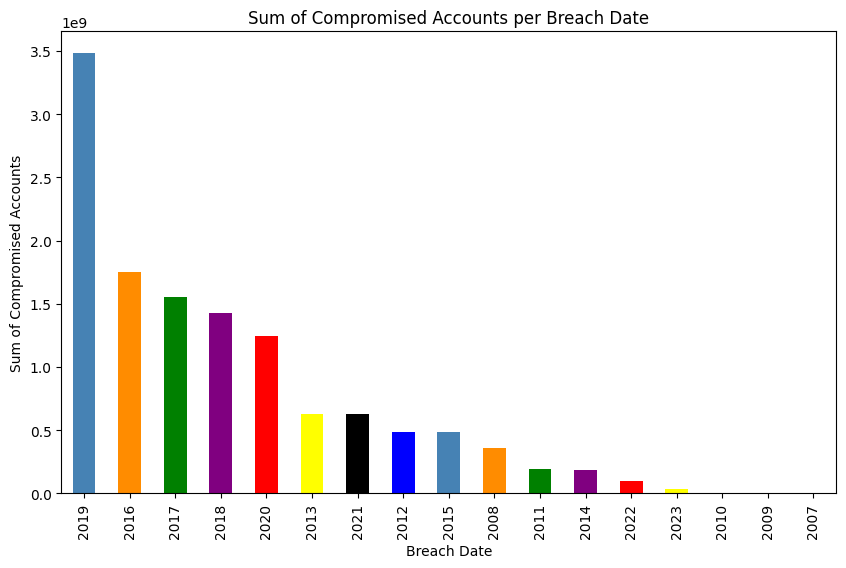

```python
# Group the dataframe by 'Breach Date' and calculate the sum of 'Compromised Accounts'
df_grouped = df_pwned.groupby('Breach Date')['Compromised Accounts'].sum()

# Sort the values in descending order
df_grouped = df_grouped.sort_values(ascending=False)

# Define custom colors for the bars
colors = ['steelblue', 'darkorange', 'green', 'purple', 'red', 'yellow', 'black', 'blue']

# Plot the graph with different colors and in descending order
ax = df_grouped.plot(kind='bar', figsize=(10, 6), color=colors)

plt.xlabel('Breach Date')
plt.ylabel('Sum of Compromised Accounts')
plt.title('Sum of Compromised Accounts per Breach Date')
plt.show()
```

```python
breach_counts = df_pwned['Breach Date'].value_counts().sort_index()
display(breach_counts)
```

```
Breach Date
2007     1
2008     3
2009     2
2010     4
2011    17
2012    18
2013    29
2014    47
2015    74
2016    95
2017    51
2018    75
2019    67
2020    88
2021    60
2022    31
2023    17
Name: count, dtype: int64
```

Though 2019 had the highest number of attacks, it did not have the highest number of breaches. This shows that the institutions that were attacked could have had larger client databases. Now if we compare both data:

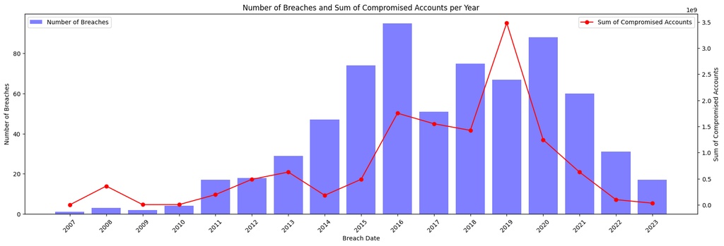

```python
# Get the number of breaches per year
breach_counts = df_pwned['Breach Date'].value_counts().sort_index()

# Group the dataframe by 'Breach Date' and calculate the sum of 'Compromised Accounts'
compromised_accounts = df_pwned.groupby('Breach Date')['Compromised Accounts'].sum()

# Plotting the data
fig, ax1 = plt.subplots(figsize=(20, 6))
ax2 = ax1.twinx()

# Plotting the number of breaches
ax1.bar(breach_counts.index, breach_counts.values, color='blue', alpha=0.5)
ax1.set_ylabel('Number of Breaches')
ax1.set_xlabel('Breach Date')

# Plotting the sum of compromised accounts
ax2.plot(compromised_accounts.index, compromised_accounts.values, marker='o', linestyle='-', color='red')
ax2.set_ylabel('Sum of Compromised Accounts')

# Set the x-axis tick labels
ax1.set_xticks(breach_counts.index)
ax1.set_xticklabels(breach_counts.index, rotation=45)

# Title and legend
plt.title('Number of Breaches and Sum of Compromised Accounts per Year')
ax1.legend(['Number of Breaches'], loc='upper left')
ax2.legend(['Sum of Compromised Accounts'], loc='upper right')

plt.show()
```

I can confirm the previous argument and add that 2016 was the Year with the most breaches, though not the year with the most data exposed.

## *Conclusion and critical evaluation*

The analysis of the dataset spanned four years, from 2019 to 2022, and revealed several important insights into cyberattacks and data breaches. Since 2020, there has been a gradual decrease in cyberattacks, but a consistent increase is observed during the third quarter (Q3) of each year. The year 2020 and Q3 experienced the highest number of cybersecurity breaches, indicating the need for enhanced security measures during this period.

The average number of data subjects affected across all incidents is approximately 5,168, and Education and childcare, retail and manufacturing, finance, insurance and credit, general business, and legal sectors are the most targeted, underscoring the need for enhanced security measures in these industries. The average time taken to report a breach is 41.0 hours, with approximately 16.2% of breaches exceeding the reporting timeframe. This highlights the importance of promptly reporting, decision-making, and timely response, which are crucial in addressing cybersecurity incidents effectively. An investigation and appropriate action should be taken to ensure the security of affected individuals and prevent further damage.

In conclusion, the dataset highlights the ongoing threat of cyberattacks and the need for proactive measures to protect sensitive data. It also underscores the importance of continuous monitoring, timely reporting, and an appropriate response to mitigate the impact of cyber incidents.

## *Ethical statement*

This project was supported by a strong commitment to ethical conduct, respecting the rights and privacy of individuals, and following legal and ethical guidelines. Throughout this project, there is manipulation of private or sensitive information that otherwise would be anonymized to protect their identities.

The *ICO* dataset is publicly available on their website, and they have no objections to its use in the public interest while maintaining individuals privacy.

*Pawned* website accepts the use of their data:

*'In other words, you're welcome to use the public API to build other services, but you must identify Have I Been Pwned as the source of the data. Clear and visible attribution with a link to haveibeenpwned.com should be present anywhere data from the service is used, including when searching breaches or pastes and when representing breach descriptions. It doesn't have to be overt, but the interface in which Have I Been Pwned data is represented should clearly attribute the source per the Creative Commons Attribution 4.0 International License.'*

The findings and insights that originated from this project should only be used for educational and analytical purposes. The results and interpretation may require caution to prevent misrepresentation or unintended consequences.

By adhering to these ethical principles, I aimed to ensure integrity and responsible conduct for my project.

## *References*

### Literature

1. Alkhalil, Z., Hewage, C., Nawaf, L. and Khan, I., 2021. Phishing attacks: A recent comprehensive study and a new anatomy. Frontiers in Computer Science, 3, p.563060.
2. Craig, A.N., Shackelford, S.J. and Hiller, J.S., 2015. Proactive cybersecurity: A comparative industry and regulatory analysis. American Business Law Journal, 52(4), pp.721-787.
3. Chigada, J. and Madzinga, R., 2021. Cyberattacks and threats during COVID-19: A systematic literature review. South African Journal of Information Management, 23(1), pp.1-11.
4. H. Koike, K. Ohno and K. Koizumi, "Visualizing cyber attacks using IP matrix," IEEE Workshop on Visualization for Computer Security, 2005. (VizSEC 05)., Minneapolis, MN, USA, 2005, pp. 91-98, doi: 10.1109/VIZSEC.2005.1532070.
5. Jensen, M.L., Dinger, M., Wright, R.T. and Thatcher, J.B., 2017. Training to mitigate phishing attacks using mindfulness techniques. Journal of Management Information Systems, 34(2), pp.597-626.
6. Kshetri, N. (2014) “Big data׳s impact on privacy, security and consumer welfare,” Telecommunications Policy, 38(11), pp. 1134–1145. Available at: https://doi.org/10.1016/j.telpol.2014.10.002.
7. Team, C. (Accessed 23/06/23) Data Breaches: Threats and Consequences. Available at: https://www.cloudmask.com/blog/data-breaches-threats-and-consequences.
8. Parmar, S.D., 2018. Cybersecurity in India: An evolving concern for national security. The Journal of Intelligence and Cyber Security, 1(1).
9. PhishMe (2017). Human phishing defense enterprise phishing resiliency and defense report 2017 analysis of susceptibility, resiliency and defense against simulated and real phishing attacks. Available at: https://cofense.com/wp-content/uploads/2017/11/Enterprise-Phishing-Resiliency-and-Defense-Report-2017.pdf.
10. Request the 2019 Q1 Data Breach QuickView Report (no date). Available at: https://pages.riskbasedsecurity.com/2019-midyear-data-breach-quickview-report.
11. Simonovich, L., 2020, 'Are utilities doing enough to protect themselves from cyber-attack?', World Economic Forum, viewed 09 May 2020, from https://www.weforum.org/agenda/2020/01/are-utilities-doing-enough-to-protect-themselves-from-cyberattack/.
12. Oz, H., Aris, A., Levi, A. and Uluagac, A.S., 2022. A survey on ransomware: Evolution, taxonomy, and defense solutions. ACM Computing Surveys (CSUR), 54(11s), pp.1-37.

### Dataset sources

1. https://haveibeenpwned.com/ - ';--have i been pwned?
2. https://ico.org.uk/action-weve-taken/data-security-incident-trends/ - Information commissioners Office

### Webscraping

1. Beautiful Soup | find_all method with Examples (no date). Available at: https://www.skytowner.com/explore/beautiful_soup_find_all_method.
2. De Wulf, P. (2022) “BeautifulSoup tutorial: Scraping web pages with Python,” ScrapingBee, 7 July. Available at: https://www.scrapingbee.com/blog/python-web-scraping-beautiful-soup/.
3. Webscraping lecture and lab, Dr Sean McGrath

### Data cleaning and processing

1. How to write UTF-8 in a CSV file (no date). Available at: https://stackoverflow.com/questions/18766955/how-to-write-utf-8-in-a-csv-file.
2. Python String replace() Method (no date). Available at: https://www.w3schools.com/python/ref_string_replace.asp.
3. pandas.to_datetime — pandas 2.0.3 documentation (no date). Available at: https://pandas.pydata.org/docs/reference/api/pandas.to_datetime.html.
4. pandas.DataFrame.fillna — pandas 2.0.3 documentation (no date). Available at: https://pandas.pydata.org/docs/reference/api/pandas.DataFrame.fillna.html.
5. pandas.DataFrame.astype — pandas 2.0.3 documentation (no date). Available at: https://pandas.pydata.org/docs/reference/api/pandas.DataFrame.astype.html.
6. pandas.DataFrame.drop — pandas 2.0.3 documentation (no date). Available at: https://pandas.pydata.org/docs/reference/api/pandas.DataFrame.drop.html.
7. pandas isnull sum with column headers (no date). Available at: https://stackoverflow.com/questions/41681693/pandas-isnull-sum-with-column-headers.
8. pandas.DataFrame.dropna — pandas 2.0.3 documentation (no date). Available at: https://pandas.pydata.org/docs/reference/api/pandas.DataFrame.dropna.html.

### Table display and Graph plotting

1. matplotlib.pyplot.subplots — Matplotlib 3.7.1 documentation (no date). Available at: https://matplotlib.org/stable/api/_as_gen/matplotlib.pyplot.subplots.html.

pandas.io.formats.style.Styler.highlight_max — pandas 2.0.3 documentation (no date). Available at: https://pandas.pydata.org/docs/reference/api/pandas.io.formats.style.Styler.highlight_max.html. 2. matplotlib.pyplot.pie — Matplotlib 3.7.1 documentation (no date). Available at: https://matplotlib.org/stable/api/_as_gen/matplotlib.pyplot.pie.html. 3. pandas.DataFrame.plot — pandas 0.23.1 documentation (no date). Available at: https://pandas.pydata.org/pandas-docs/version/0.23/generated/pandas.DataFrame.plot.html. 4. pandas reset_index after groupby.value_counts() (no date). Available at: https://stackoverflow.com/questions/39778686/pandas-reset-index-after-groupby-value-counts. 5. pandas.DataFrame.sort_values — pandas 2.0.3 documentation (no date). Available at: https://pandas.pydata.org/docs/reference/api/pandas.DataFrame.sort_values.html. 6. Python, R. (2023) “Python enumerate(): Simplify Loops That Need Counters,” realpython.com [Preprint]. Available at: https://realpython.com/python-enumerate/. 7. seaborn.barplot — seaborn 0.12.2 documentation (no date). Available at: https://seaborn.pydata.org/generated/seaborn.barplot.html.

## *Glossary*

### Columns

| Term | Definition |
| --- | --- |
| 'Quarter' | Period time where data was collected. |
| 'Data subject type' | The type of person affected by the breach - eg customers, employees or children. More details about these categories are given in Data subject type. |
| 'Data Type' | The category of data that has been compromised by the breach. This includes whether the data is special category data or data about criminal convictions. These data types are detailed in Data type. |
| 'Decision Taken' | The ICO determined that action was needed in response to the breach report. This action could be formal or informal. Details of the type of action possible are outlined in Decision taken. |
| 'Incident Category' | Whether the incident was categorised as cyber or non-cyber. Described in detail in Incident categories. |
| 'Incident Type' | How the breach occurred and whether it was a deliberate act that led to the breach or an error. These are broken down and described in Incident types. |
| 'No. Data Subjects Affected' | Data subjects whose personal data has been impacted as a result of the breach. This does not include, for example, incorrect recipients of another individual’s data. At the time of reporting, it may n… |
| 'Sector' | the type of organisation that reported the breach. These are not defined in detail as there are a number of inconsistencies in how these are used, particularly within the historic data. We are working… |
| 'Time Taken to Report' | How long in hours it took an organisation to report a breach after it had been discovered. |

```python
dataSubjectType = df2['Data Subject Type'].unique()
dataSubjectType.sort()
dataSubjectType
```

```
array(['Children', 'Customers or prospective customers', 'Employees',
       'Patients', 'Students', 'Subscribers', 'Unknown', 'Users',
       'Vulnerable adults'], dtype=object)
```

### Data subject type

| Term | Definition |
| --- | --- |
| 'Children' | Personal data about individuals under the age of 18. Children’s data have additional protections under the UK GDPR and the Children’s code. |
| 'Customers or prospective customers' | Information about those that use a company’s services or have enquired about their services. For example, a retailer could hold a database of individuals that have used their services or browsed their… |
| 'Employees' | Information collected about members of staff within an organisation. This could include financial information and special category data, depending on the information collected. |
| 'Patients' | Individuals that have used medical services. This could be for physical or mental health problems, dental services or other treatments. This data is likely to contain special category data. |
| 'Students' | Children or adults that are studying at an educational facility, such as a school, college or university. |
| 'Subscribers' | Individuals that have signed up for a regular service, such as newsletters or products. These people may or may not also be customers, depending on the services they have signed up for. |
| 'Unknown' |  |
| 'Users' | Individuals that use a service, such as a social media platform or forum. Users have signed up but are not purchasing a product or receiving a regular service. |
| 'Vulnerabel adults' | Adults that have additional needs or are otherwise disadvantaged leaving them in a vulnerable position. This could be due to disability, mental illness, abuse, or other issues that may require additio… |

```python
dataType = df2['Data Type'].unique()
dataType.sort()
dataType
```

```
array(['Basic personal identifiers', 'Criminal convictions or offences',
       'Data revealing racial or ethnic origin',
       'Economic and financial data', 'Gender Reassignment Data',
       'Genetic or biometric data', 'Health data', 'Identification data',
       'Location data', 'Official documents', 'Political opinions',
       'Religious or philosophical beliefs', 'Sex life data',
       'Sexual orientation data', 'Trade union membership', 'Unknown'],
      dtype=object)
```

### Data type

| Terms | Definition |
| --- | --- |
| 'Basic personal identifiers' | Information, such as name, email address, or address, that can identify an individual. This does not include information that is of a more sensitive nature. |
| 'Criminal convictions or offences' | Information about any illegal behaviour an individual may have been suspected or convicted of. This could include information about appearances on the sexual offences register, for example. Article 10… |
| 'Data revealing racial or ethnic origin' | Information that reveals a person’s or group of people’s race or ethnicity. This information is considered special category data in accordance with Article 9 of the UK GDPR. |
| 'Economic and financial data' | Data relating to an individual’s or group of individual’s credit card, bank account, or other financial data. This could include information such as pay or rates of benefits they receive. Although peo… |
| 'Gender Reassignment Data | information about those who have transitioned or are transitioning between genders. This may also include that the person identifies as non-binary or another gender type. This information is considere… |
| 'Genetic or biometric data' | Information relating to physical, psychological or behavioural characteristics that can uniquely identify an individual. This can include data such as fingerprints, iris scans, genetic, or other biolo… |
| 'Health data' | Information relating to the physical or mental health of an individual. This includes information about health services that an individual may have accessed and that may reveal details of their health… |
| 'Identification data' | Information that is used to identify an individual. This may not be a name, but could also be a customer number or username that can be combined with other information to uniquely identify a person. |
| 'Location data' | Information such as geolocation data that can identify where a person lives, works or otherwise spends their time. As this data can be used to track someone’s movements, it can in turn help identify i… |
| 'Official documents' | Copies of paperwork such as driver’s licenses, birth certificates and passports that can be used as proof of identification. |
| 'Political opinions' | Details about an individual’s voting history or political party membership. This information is considered special category data in accordance with Article 9 of the UK GDPR. |
| 'Religious or philosophical beliefs' | Details of the belief systems that an individual or group of individuals have. This could be whether they are a member of a particular religious group or whether they are atheist. This information is … |
| 'Sex life data' | Any data on a person’s sex life which does not specifically relate to orientation or health. This could include whether they have signed up to dating apps or a period tracker, for example. |
| 'Sexual orientation data' | Information about someone’s sexual preferences, such as whether they identify as gay, straight, bisexual, asexual, or any other sexual orientation that they feel describes them best. This information … |
| 'Trade union membership' | Whether someone holds or has held membership to a union. This information is considered special category data in accordance with Article 9 of the UK GDPR. |
| 'Unknown' |  |

```python
decisionTaken = df2['Decision Taken'].unique()
decisionTaken.sort()
decisionTaken
```

```
array(['Informal Action Taken', 'Investigation Pursued',
       'No Further Action', 'Not Yet Assigned'], dtype=object)
```

### Decisions taken

| Terms | Definition |
| --- | --- |
| 'Informal Action Taken' | We have determined that the breach as reported did not warrant use of our formal powers, such as a fine or reprimand. However, we did feel that some action was required, such as advice given. (Note: w… |
| 'Investigation Pursued' | The case is passed to our investigations or cyber investigations teams in order to determine what action, if any, is suitable in a particular case. This may not necessarily lead to a full investigatio… |
| 'No Further Action' | The investigations team has determined that no further action is required in response to the report. This could be because the issue did not involve any personal data or did not reach the threshold fo… |
| 'Not Yet Assigned' |  |

```python
incidentCategory = df2['Incident Category'].unique()
incidentCategory.sort()
incidentCategory
```

```
array(['Cyber'], dtype=object)
```

### Incident Category

| Terms | Definition |
| --- | --- |
| 'Cyber' | an umbrella term describing a type of breach with a clear online or technological element which involves a third party with malicious intent. For example, incidents involving phishing or malware attac… |
| 'Non Cyber' | an umbrella term describing a type of breach that does not have a clear online or technological element which involves a third party with malicious intent. For example, incidents involving paper filin… |

```python
incidentTypes = df2['Incident Type'].unique()
incidentTypes.sort()
incidentTypes
```

```
array(['Brute Force', 'Denial of service', 'Malware',
       'Other cyber incident', 'Phishing', 'Ransomware',
       'Unauthorised access'], dtype=object)
```

### Incident Types

| Terms | Definition |
| --- | --- |
| 'Alteration of personal data' | When personal data has been unlawfully changed. This could be, for example, data that is incorrectly updated on a system accidentally or deliberately. |
| 'Brute Force' | When an attacker tries a large number of possible keyword or password combinations to gain unauthorised access to a system or file. |
| 'Cryptographic flaw' | A weakness in the security of a system that would allow a hacker to access sensitive information. |
| 'Data emailed to incorrect recipient' | Where an email containing personal data is sent to the wrong email address. This could be data about one person or multiple individuals. |
| 'Data of wrong data subject shown in client portal' | Where personal information about one or more individuals is shown within the Online service area belonging to another person. |
| 'Data posted or faxed to incorrect recipient' | Where a fax or piece of post containing personal data is sent to the wrong fax number or postal address. This could be data about one person or multiple individuals. |
| 'Denial of service' | When a network or server, such as a website, is maliciously flooded with manufactured traffic (typically using botnets) to either cause it to fail or flood it with so much traffic that legitimate user… |
| 'Failure to redact' | When personal data was disclosed without the appropriate redaction, or if the redactions made were inadequate. |
| 'Failure to use bcc' | When personal data was disclosed due to an organisation not using blind carbon copy (bcc) recipients in an email. Usually bcc is used to ensure personal email addresses are not shared inappropriately … |
| 'Hardware/software misconfiguration' | Any hardware or software misconfiguration leading to a disclosure of information. For example, permissions on a folder set incorrectly, or failing to use a robot.txt file. |
| 'Incorrect disposal of hardware' | Computers, laptops or other devices are not fully cleared of personal data or had any personal data it contains otherwise anonymised or encrypted. |
| 'Incorrect disposal of paperwork' | Paperwork containing personal data has been disposed of without it being shredded or otherwise destroyed. Personal information should not be identifiable once paper files have been disposed of. |
| 'Loss/theft of device containing personal data' | An electronic device (for example laptop, phone or tablet) containing personal information of others has been misplaced or stolen. This may be of particular concern if the data is not sufficiently sec… |
| 'Loss/theft of paperwork or data left in insecure location' | Papers containing personal data are not secured, for example locking the paperwork in a cabinet or similar; or papers are misplaced or stolen. |
| 'Malware' | A general term used to refer to a variety of forms of hostile or intrusive software including computer viruses, worms, Trojan horses, spyware, adware, scareware, and other malicious programs. Malware … |
| 'Not Provided' |  |
| 'Other cyber incident' |  |
| 'Other non-cyber incident' |  |
| 'Phishing' | An attempt to obtain information by posing as a trustworthy entity, deceiving recipients into sharing sensitive information (such as usernames, passwords, or credit card details) or by encouraging the… |
| 'Ransomware' | A type of malware that unlawfully encrypts a user’s files and demands a ransom to unencrypt files, usually in the form of cryptocurrency. |
| 'Unauthorised access' | An unauthorised individual has gained access to personal data. This can include unauthorised disclosures. This incident type is used both in instances where an individual has unlawfully accessed or di… |
| 'Verbal disclosure of personal data' | When personal data is shared or disclosed verbally to an inappropriate party. |

```python
sector = df2['Sector'].unique()
sector.sort()
sector
```

```
array(['Central Government', 'Charitable and voluntary',
       'Education and childcare', 'Finance, insurance and credit',
       'General business', 'Health', 'Justice',
       'Land or property services', 'Legal', 'Local government',
       'Marketing', 'Media', 'Membership association',
       'Online Technology and Telecoms', 'Political', 'Regulators',
       'Religious', 'Retail and manufacture', 'Social care',
       'Transport and leisure', 'Unassigned', 'Utilities'], dtype=object)
```

### Sector

| Terms | Definition |
| --- | --- |
| 'Central Government' | Highest governing authority responsible for policy-making and administration at the national level. |
| 'Charitable and voluntary' | Organizations and activities driven by volunteers to support those in need or promote social welfare without seeking profit. |
| 'Finance insurance and credit' | Industry and institutions managing financial transactions, providing insurance, and facilitating credit services. |
| 'General business' | Involves commercial activities across industries, encompassing functions like strategy, marketing, finance, operations, and human resources. |
| 'Health' | Industry, institutions, and professionals providing healthcare services to promote well-being and treat illnesses. |
| 'Justice' | Institutions and processes responsible for upholding and administering justice within a society, including legal systems, courts, law enforcement, and correctional facilities. |
| 'Land or property services' | Industry and organizations involved in land and property management, transactions, and services, including real estate agencies, developers, surveyors, appraisers, and registries. |
| 'Legal' | Industry, institutions, and professionals providing legal services and administering the law. |
| 'Local government' | Authorities and bodies responsible for local governance and service provision at the regional or municipal level. |
| 'Marketing' | Industry and activities involved in promoting and selling products or services to customers through market research, advertising, branding, sales, and customer relationship management. |
| 'Media' | Industry and organizations involved in creating, distributing, and consuming various forms of media, including traditional and digital platforms, for news, entertainment, and information purposes. |
| 'Membership association' | Organizations formed by individuals or groups with shared interests, providing resources, support, and representation to their members. |
| 'Online Technology and Telecoms' | Industry and organizations involved in the development, provision, and utilization of digital technologies and telecommunications services. |
| 'Political' | Refers to the sphere of activities and institutions involved in governance, policy-making, and political decision-making within a society. |
| 'Regulators' | Organizations responsible for overseeing and enforcing regulations in specific industries or sectors. |
| 'Religious' | Organizations and institutions involved in practicing and promoting religious beliefs and faith-based activities. |
| 'Retail and manufacture' | Industry and organizations involved in the production and sale of goods to consumers. |
| 'Transport and leisure' | Industry and organizations involved in providing transportation services and leisure activities. |
| 'Social care' | Organizations and services dedicated to providing support and assistance to individuals with social, physical, or mental care needs. |
| 'Unassigned' |  |
| 'Utilities' | Industry and organizations involved in the provision of essential public services such as electricity, water, gas, and telecommunications. |